# Дипломный проект. Интернет-магазин товаров для дома «Пока все ещё тут»

**Основная задача:** выявление профилей потребления.

**Основная цель:** предоставить комплексный анализ и рекомендации, которые позволят увеличить продажи и лояльность клиентов путем сегментированного маркетинга.

**Дополнительные цели:**

1. Рекомендации по маркетингу: исходя из анализа сегментов покупателей, разработать рекомендации о том, каким клиентам и когда следует рассылать рекламные предложения о каких категориях товаров.
2. Стратегия увеличения продаж: разработать стратегию по увеличению количества продаваемого товара для каждого сегмента.
3. Стратегия повышения лояльности: предложить способы повышения возвращаемости покупателей для различных сегментов.

### **План иссделовавния**

- Предобработка данных
- Исследовательский анализ данных
  - количество заказов и покупателей
  - добавление столбца "сумма по позиции"
  - добавление столбца "категория товара"
  - добавление столбца "сезон"
  - изучение аномалий
- Основные вопросы исследования
  - Выделите основные показатели интернет-магазина:
    - динамику выручки
    - средний чек и его динамику
    - помесячную динамику средней выручки с покупателя
  - Сегментация покупателей на основе истории их покупок
    - сегментация покупателей на основе RFM подхода
    - анализ сегментов (количество покупателей, средний чек, основные продукты и категории)
    - анализ категорий товаров и их сезонность по выделенным сегментам покупателей
- Проверка гипотез
  - H<sub>0</sub>: Сегменты клиентов не различаются по категориям товаров
  - H<sub>1</sub>: Сегменты клиентов различаются по категориям товаров
  - H<sub>0</sub>: Сегменты клиентов не различаются по среднему чеку
  - H<sub>1</sub>: Сегменты клиентов различаются по среднему чеку
- Выводы и рекомендации

**Описание данных базы данных ecom_dataset_upd.csv:**

- date — дата заказа;
- customer_id — идентификатор покупателя;
- order_id — идентификатор заказа;
- product — наименование товара;
- quantity — количество товара в заказе;
- price — цена товара.

```python
# Импортируем библиотеки

import pandas as pd
import numpy as np
from datetime import datetime, timedelta
from matplotlib import pyplot as plt
import matplotlib.dates as mdates
import seaborn as sns
import math
import scipy.stats as st
import warnings
import random

# интернет запросы
import requests

# парсеры
import lxml
from bs4 import BeautifulSoup
```

```python
# Глабальные настройки по умолчинию для проекта

# игнорируем ненужные предупреждения
warnings.filterwarnings("ignore")

# применяем тему для графиков по умолчинию

# повысим качество изображения графиков
%config InlineBackend.figure_format='retina'

# Настройки графиков
sns.set_theme(style='whitegrid', palette='Set2', rc={'figure.figsize':(12, 6)})
```

## Предобработка данных

```python
df = pd.read_csv('https://code.s3.yandex.net/datasets/ecom_dataset_upd.csv')
```

Изучите общую информацию о датасете

```
<class 'pandas.core.frame.DataFrame'>
RangeIndex: 7474 entries, 0 to 7473
Data columns (total 6 columns):
 #   Column       Non-Null Count  Dtype
---  ------       --------------  -----
 0   date         7474 non-null   int64
 1   customer_id  7474 non-null   object
 2   order_id     7474 non-null   int64
 3   product      7474 non-null   object
 4   quantity     7474 non-null   int64
 5   price        7474 non-null   float64
dtypes: float64(1), int64(3), object(2)
memory usage: 350.5+ KB
----------------------------------------------------------------------------------------------------
```

|  | date | customer_id | order_id | product | quantity | price |
| --- | --- | --- | --- | --- | --- | --- |
| 0 | 2018100100 | ee47d746-6d2f-4d3c-9622-c31412542920 | 68477 | Комнатное растение в горшке Алое Вера, d12, h30 | 1 | 142.0 |
| 1 | 2018100100 | ee47d746-6d2f-4d3c-9622-c31412542920 | 68477 | Комнатное растение в горшке Кофе Арабика, d12,... | 1 | 194.0 |
| 2 | 2018100100 | ee47d746-6d2f-4d3c-9622-c31412542920 | 68477 | Радермахера d-12 см h-20 см | 1 | 112.0 |
| 3 | 2018100100 | ee47d746-6d2f-4d3c-9622-c31412542920 | 68477 | Хризолидокарпус Лутесценс d-9 см | 1 | 179.0 |
| 4 | 2018100100 | ee47d746-6d2f-4d3c-9622-c31412542920 | 68477 | Циперус Зумула d-12 см h-25 см | 1 | 112.0 |

|  | date | customer_id | order_id | product | quantity | price |
| --- | --- | --- | --- | --- | --- | --- |
| 7469 | 2020013021 | 63208953-a8e4-4f77-9b47-3a46e7b72eee | 104002 | томата (помидор) Черниченский черри № 116 сорт... | 2 | 38.0 |
| 7470 | 2020013022 | d99d25f1-4017-4fcd-8d29-c580cc695a1a | 107336 | Дендробиум Санок Анна Грин 1 ствол d-12 см | 1 | 869.0 |
| 7471 | 2020013102 | 2c9bd08d-8c55-4e7a-9bfb-8c56ba42c6d6 | 106336 | Подставка для обуви резиновая Attribute 80x40 ... | 1 | 354.0 |
| 7472 | 2020013112 | cdd17932-623e-415f-a577-3b31312fd0e2 | 102002 | Тагетис крупноцветковый рассада однолетних цве... | 1 | 128.0 |
| 7473 | 2020013115 | 2e460a26-35af-453d-a369-a036e95a40e0 | 103225 | Вешалка для блузок 41 см красный Attribute AHM781 | 1 | 104.0 |

```
----------------------------------------------------------------------------------------------------
Количество строк-дубликатов: 0
----------------------------------------------------------------------------------------------------
Количество пропусков по столбцам
```

```
date           0.0
customer_id    0.0
order_id       0.0
product        0.0
quantity       0.0
price          0.0
dtype: float64
```

|  | count | mean | std | min | 25% | 50% | 75% | 90% | 95% | 99% | max |
| --- | --- | --- | --- | --- | --- | --- | --- | --- | --- | --- | --- |
| date | 7474.0 | 2.018913e+09 | 427887.840663 | 2.018100e+09 | 2.019022e+09 | 2.019051e+09 | 2.019063e+09 | 2.019103e+09 | 2.019122e+09 | 2.020012e+09 | 2.020013e+09 |
| order_id | 7474.0 | 4.944988e+04 | 32679.642404 | 1.262400e+04 | 1.483300e+04 | 6.876800e+04 | 7.125775e+04 | 7.314370e+04 | 1.071488e+05 | 1.117655e+05 | 1.127890e+05 |
| quantity | 7474.0 | 2.362858e+00 | 14.500497 | 1.000000e+00 | 1.000000e+00 | 1.000000e+00 | 1.000000e+00 | 2.000000e+00 | 5.000000e+00 | 2.500000e+01 | 1.000000e+03 |
| price | 7474.0 | 4.787375e+02 | 901.615895 | 9.000000e+00 | 9.700000e+01 | 1.350000e+02 | 4.390000e+02 | 1.199000e+03 | 1.987000e+03 | 4.614500e+03 | 1.491700e+04 |

|  | count | unique | top | freq |
| --- | --- | --- | --- | --- |
| customer_id | 7474 | 2451 | 1d6c8c1f-a799-4418-9af2-1ded47d7a85c | 888 |
| product | 7474 | 2343 | Рассада Кабачка сорт Зебра кассета 6 шт E6 | 79 |

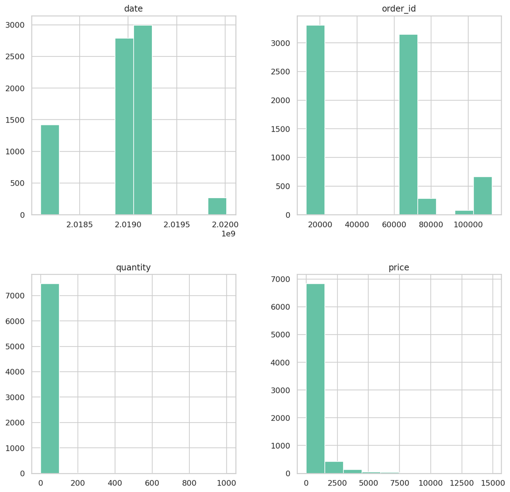

```python
sep = '-'
repiat = 100
df.info() # общая информация
print(sep*repiat)
display(df.head()) # первые пять строк
display(df.tail()) # последние пять строк
print(sep*repiat)
print('Количество строк-дубликатов:', df.duplicated().sum()) # количество явных дулбикатов
print(sep*repiat)
print('Количество пропусков по столбцам')
display(df.isna().mean() * 100) # количество пропусков
print(sep*repiat)
display(df.describe(percentiles=[.25, .5, .75, .9, .95, .99],
                    include=[np.number]).T) # описание числовых полей
display(df.describe(exclude=[np.number]).T) # описание нечисловых полей
print(sep*repiat)
df.hist(figsize=(12, 12)); # гистограмма для числовых полей
plt.show() # гистограмма для числовых полей
```

Количество записей в датасете 7474. Пропусков и явных дубликатов в датасете нет. Типы данных определены корректно, кроме столбца дата, в котором формат записи "2018100100" значит 2018-10-01 и 00 ч. Переведем его в тип данных дата. Есть выбросы в столбце количество единиц товара - 99% процентиль равнен 25. Также в столбце цена наблюдаются выбросы - 99% процентиль равнен 4614,5. Изучим их подробнее далее.

```python
# переводим в дататайм столбец дата
df.date = pd.to_datetime(df.date, format='%Y%m%d%H')
df.date[:5]
```

```
0   2018-10-01
1   2018-10-01
2   2018-10-01
3   2018-10-01
4   2018-10-01
Name: date, dtype: datetime64[ns]
```

Изучим, за какой период мы располагаем данными

```python
print('Данные с', df.date.min(), "по", df.date.max())
```

```
Данные с 2018-10-01 00:00:00 по 2020-01-31 15:00:00
```

Исследуем наличие неявных дубликатов в столбце ID покупателя с группированием по номеру заказа.

```python
df.groupby('order_id').agg({'customer_id':'nunique'}).query('customer_id > 1').sort_values(by='customer_id', ascending=False).describe().T
```

|  | count | mean | std | min | 25% | 50% | 75% | max |
| --- | --- | --- | --- | --- | --- | --- | --- | --- |
| customer_id | 29.0 | 2.137931 | 0.441114 | 2.0 | 2.0 | 2.0 | 2.0 | 4.0 |

Всего 29 заказов, где более одного покупателя. Исследуем эти дубликаты.

```python
with pd.option_context("display.max_rows", None, 'display.max_colwidth', None):
    display((df[df['order_id'].isin(df.groupby('order_id')
                                        .agg({'customer_id':'nunique'})
                                        .query('customer_id > 1')
                                        .index)]
             .drop_duplicates(subset=['order_id', 'customer_id'])
             .sort_values(by=['order_id', 'customer_id'])))
```

|  | date | customer_id | order_id | product | quantity | price |
| --- | --- | --- | --- | --- | --- | --- |
| 5518 | 2019-06-21 22:00:00 | 4e861452-b692-48dc-b756-99a130b7a70a | 14872 | Однолетнее растение Петуния махровая в кассете 4 шт, Россия | 2 | 82.0 |
| 5549 | 2019-06-24 09:00:00 | 9897ccd6-9441-4886-b709-b06361fabf6c | 14872 | Однолетнее растение Петуния махровая в кассете 4 шт, Россия | 2 | 82.0 |
| 512 | 2018-10-28 22:00:00 | 0b5ce2c7-acef-4a9a-b821-61a44ed05557 | 68785 | Сиденье в ванну раздвижное, белый, СВ5, НИКА | 1 | 374.0 |
| 538 | 2018-10-30 21:00:00 | c1dd5c0e-51db-4a5d-91a3-5374cb20043d | 68785 | Сиденье в ванну раздвижное, белый, СВ5, НИКА | 1 | 374.0 |
| 1154 | 2018-12-10 12:00:00 | 2f955596-4b13-432e-93f3-6433395aafe6 | 69283 | Сушилка для белья на батарею НИКА СБ6-65 двухъярусная | 1 | 164.0 |
| 1160 | 2018-12-10 16:00:00 | e3805ccd-2d64-4d0e-92dd-902293555c35 | 69283 | Сушилка для белья на батарею НИКА СБ6-65 двухъярусная | 1 | 164.0 |
| 1674 | 2019-02-03 22:00:00 | 845d52ce-9420-4c44-b4b5-3fb55c792084 | 69310 | Муляж Груша желтый 9,5 см полиуретан | 7 | 59.0 |
| 1177 | 2018-12-11 21:00:00 | 954172a5-634c-4a50-941d-9db6d15a7377 | 69310 | Муляж Груша желтый 9,5 см полиуретан | 7 | 59.0 |
| 1209 | 2018-12-15 07:00:00 | 22e4d79f-3613-4c22-8b01-7f880120bf5a | 69345 | Сушилка для белья Attribute ПРИМА 18 м синяя ADP618 | 1 | 974.0 |
| 1196 | 2018-12-13 19:00:00 | 70d60304-4b3c-4f34-9430-1872ec6e6309 | 69345 | Сушилка для белья Attribute ПРИМА 18 м синяя ADP618 | 1 | 974.0 |
| 1237 | 2018-12-17 14:00:00 | 4ea06f66-0876-4dec-8d14-ea994ffe435f | 69410 | Муляж Желудь 2 шт | 3 | 22.0 |
| 1258 | 2018-12-18 20:00:00 | caaa3f41-c9ab-4e3d-8b75-94e1d3a8d7b4 | 69410 | Муляж Желудь 2 шт | 3 | 22.0 |
| 1292 | 2018-12-21 11:00:00 | 266beb08-ec9b-43b4-89bb-ac60fa23ffee | 69485 | Набор столовых приборов 24 предмета FARANDOLE Domenik DM9635 | 1 | 1274.0 |
| 1282 | 2018-12-20 16:00:00 | 5be0f4b4-947f-4672-b147-73ef5936ecd4 | 69485 | Набор столовых приборов 24 предмета SAINT GERMAIN Domenik DM9638 | 1 | 1087.0 |
| 1384 | 2018-12-26 23:00:00 | e0461045-4fcc-4731-8837-509f6534512a | 69485 | Набор столовых приборов 24 предмета FARANDOLE Domenik DM9635 | 1 | 1274.0 |
| 1449 | 2019-01-07 09:00:00 | 2273b174-e223-415a-9be1-49d19abea06e | 69531 | Сумка-тележка хозяйственная Rolser BAB010 rojo JOY-1800 красная | 1 | 4139.0 |
| 1323 | 2018-12-23 14:00:00 | e382d4c4-a4c9-44d3-97a0-a8868e122563 | 69531 | Сумка-тележка хозяйственная Rolser BAB010 rojo JOY-1800 красная | 1 | 4139.0 |
| 1519 | 2019-01-15 17:00:00 | 631c5729-d163-4270-8956-4d9832085d0e | 69833 | Чехол Eurogold Clean Metallic металлизированый с поролоном для досок 120х38-120х42 см C42F3M | 2 | 299.0 |
| 1583 | 2019-01-23 19:00:00 | a684bf62-f75c-4e82-aa74-6d02b127b439 | 69833 | Чехол Eurogold Clean Metallic металлизированый с поролоном для досок 120х38-120х42 см C42F3M | 2 | 299.0 |
| 1706 | 2019-02-05 20:00:00 | 673d44a3-9cec-4c2f-b0c6-9be4952ddc7c | 70114 | Вешалка-плечики без эссенции цвет тёмно-розовый FWM-002/Quartz pink | 30 | 40.0 |
| 1764 | 2019-02-09 20:00:00 | b827d1a8-5e5d-4a44-9813-2bd669471a73 | 70114 | Вешалка-плечики без эссенции цвет тёмно-розовый FWM-002/Quartz pink | 30 | 40.0 |
| 2276 | 2019-03-10 22:00:00 | 00c95d20-923e-4b45-88fc-53b12931d462 | 70542 | Миксер электрический погружной DELTA DL-5061 белый с сиреневым 300 Вт 5 скоростей | 1 | 959.0 |
| 2118 | 2019-03-01 19:00:00 | b883aae0-25ef-4c5c-8d35-4c6ae8517f1c | 70542 | Миксер электрический погружной DELTA DL-5061 белый с сиреневым 300 Вт 5 скоростей | 1 | 959.0 |
| 2211 | 2019-03-06 13:00:00 | 411ab440-0631-422d-9999-8d5ef8cec0e2 | 70631 | Искусственная композиция из цветов пластиковая мини елочка зеленая с голубым | 1 | 74.0 |
| 2228 | 2019-03-07 07:00:00 | d1bf7700-6afa-4297-9220-48e6aa0d7e2c | 70631 | Искусственная композиция из цветов пластиковая мини елочка зеленая с голубым | 1 | 74.0 |
| 2323 | 2019-03-14 07:00:00 | 95d61179-404e-4ebd-9762-29d800b1583e | 70726 | Пеларгония розебудная Red Pandora укорененный черенок | 2 | 134.0 |
| 2322 | 2019-03-14 05:00:00 | af96cc67-1726-43ba-bca1-1da7b78cb33a | 70726 | Пеларгония розебудная Red Pandora укорененный черенок | 2 | 134.0 |
| 2409 | 2019-03-20 15:00:00 | 78e8c0e7-4888-4a75-8137-a90f02a6cb8c | 70808 | Тележка багажная DELTA ТБР-20 черный с серым грузоподъемность 25 кг сумка 50 кг каркас РОССИЯ | 1 | 727.0 |
| 2410 | 2019-03-20 16:00:00 | ad1630b2-fc36-4961-900a-46612ff6c655 | 70808 | Тележка багажная DELTA ТБР-20 черный с серым грузоподъемность 25 кг сумка 50 кг каркас РОССИЯ | 1 | 727.0 |
| 2491 | 2019-03-28 10:00:00 | 5e5a3e1a-0388-4131-a770-f6e3b696985b | 70903 | Средство против засоров в системах водопровода DECS Антизасор 1000 мл Россия 4660015923303 | 1 | 104.0 |
| 3344 | 2019-05-01 01:00:00 | 718316fc-bdf3-4d1d-b8f1-a5c763238ff4 | 70903 | Средство против засоров в системах водопровода DECS Антизасор 1000 мл Россия 4660015923303 | 1 | 142.0 |
| 2579 | 2019-04-01 09:00:00 | 6a4d397b-8f89-4382-89b3-9ef535eee80d | 70946 | Пеларгония розебудная Prins Nikolai укорененный черенок | 1 | 134.0 |
| 3467 | 2019-05-08 16:00:00 | 753660bf-a1ea-4447-853d-622e47c1c6ac | 70946 | Пеларгония розебудная Prins Nikolai укорененный черенок | 1 | 134.0 |
| 4609 | 2019-06-05 09:00:00 | 34572907-a445-4b40-b1b6-fd0cbfa653b1 | 71054 | Вешалка-плечики без эссенции цвет тёмно-розовый FWM/L-Pink | 10 | 43.0 |
| 2720 | 2019-04-07 19:00:00 | d713f977-a28f-4c34-ae9a-d132068e64f3 | 71054 | Вешалка-плечики без эссенции цвет тёмно-розовый FWM/L-Pink | 10 | 43.0 |
| 2996 | 2019-04-21 15:00:00 | c912fec9-fd4f-41b7-bb04-4548740b276b | 71226 | Сушилка для белья напольная НИКА СБ3Б 10 м белая | 1 | 569.0 |
| 2998 | 2019-04-21 19:00:00 | fd4af93f-9fbd-449f-91f8-b42b830e265b | 71226 | Сушилка для белья напольная НИКА СБ3Б 10 м белая | 1 | 569.0 |
| 3932 | 2019-05-19 19:00:00 | 79162ad6-b2f0-491a-b3fb-2376c9001b63 | 71461 | Коврик придверный с дизайном, из резины и кокоса 58,5*89 Gothic Iron Slice / Готический Узор, 4468 | 1 | 1642.0 |
| 3937 | 2019-05-20 08:00:00 | 9ecc5887-b4d4-4cea-b446-88748df71d9c | 71461 | Коврик придверный с дизайном, из резины и кокоса 58,5*89 Gothic Iron Slice / Готический Узор, 4468 | 1 | 1642.0 |
| 3963 | 2019-05-21 02:00:00 | 4bd9c1e8-b2cc-4ec5-97eb-28d8f3c22d8d | 71480 | Мята перечная Шоколадная Chocolate d-7 см h-10 см укорененный черенок | 1 | 74.0 |
| 4026 | 2019-05-25 02:00:00 | 51f04abe-a71a-4694-87b7-ad9ef4930e51 | 71480 | Мята перечная Шоколадная Chocolate d-7 см h-10 см укорененный черенок | 1 | 74.0 |
| 4025 | 2019-05-24 22:00:00 | d8080f8f-3685-433b-b416-beb0a8f06606 | 71480 | Мята перечная Шоколадная Chocolate d-7 см h-10 см укорененный черенок | 1 | 74.0 |
| 6064 | 2019-08-07 10:00:00 | 52ca850d-ce65-4445-bddc-b0b063b13ba7 | 71542 | Салатник Luminarc КУТЮР 27 см H3529 | 1 | 299.0 |
| 4089 | 2019-05-28 21:00:00 | 5ee242e4-7610-43bc-88a6-6ae2d886797f | 71542 | Салатник Luminarc КУТЮР 27 см H3529 | 1 | 299.0 |
| 4298 | 2019-06-02 10:00:00 | 95872093-2887-4ce8-8468-19234990e7d7 | 71571 | Бегония Элатиор, цвет в ассортименте | 1 | 187.0 |
| 4297 | 2019-06-02 10:00:00 | f1222eaa-d09d-4bff-ab4e-bea6fe3f68a8 | 71571 | Бегония Элатиор, цвет в ассортименте | 1 | 187.0 |
| 4909 | 2019-06-09 07:00:00 | 6921ac3e-bfcd-4a05-95d3-12ef81e874cc | 71648 | Сушилка для белья потолочная ЛИАНА ЛЮКС 250 см ЛЛП-250 | 1 | 704.0 |
| 5343 | 2019-06-15 14:00:00 | a843e87d-c9b8-475a-96fb-1edcccca5f8e | 71648 | Сушилка для белья потолочная ЛИАНА ЛЮКС 250 см ЛЛП-250 | 1 | 704.0 |
| 5020 | 2019-06-10 13:00:00 | 11a9ee7f-c1af-48eb-ab82-bfe5dbc0ab02 | 71663 | Пеларгония розебудная Prins Nikolai укорененный черенок | 1 | 134.0 |
| 6257 | 2019-09-05 12:00:00 | a7ef9c85-57e1-45ad-89c9-8b405339d4c8 | 71663 | Пеларгония розебудная Prins Nikolai укорененный черенок | 1 | 134.0 |
| 6030 | 2019-08-03 13:00:00 | 55b8d928-77f8-40fc-a2e9-08424d13b0e4 | 72188 | Муляж Персики мини полиуретан d-6 см | 1 | 22.0 |
| 6026 | 2019-08-02 15:00:00 | da6f7bf7-f699-4046-a4dd-cab0c27debcb | 72188 | Муляж Персики мини полиуретан d-6 см | 1 | 22.0 |
| 6576 | 2019-10-10 22:00:00 | 31a39955-8a93-42f3-8839-04a9693632a7 | 72778 | Шеффлера Голд Капелла d-12 см h-25 см | 1 | 149.0 |
| 6440 | 2019-09-27 00:00:00 | 9777b839-4212-41bb-94c2-87de3658248a | 72778 | Шеффлера Голд Капелла d-12 см h-25 см | 1 | 149.0 |
| 6474 | 2019-09-30 09:00:00 | 07b63f16-aa4a-4acc-a7a5-af941fd4b0a9 | 72790 | Сушилка для белья потолочно-настенная Gimi Lift 160 | 1 | 1424.0 |
| 6447 | 2019-09-28 10:00:00 | a3d7fb5c-d3fb-40d6-b060-47a7061ca442 | 72790 | Сушилка для белья потолочно-настенная Gimi Lift 160 | 1 | 1424.0 |
| 6505 | 2019-10-03 15:00:00 | 0309d37c-ab5f-4793-ba72-5484c019b840 | 72845 | Муляж Яблоко зеленый 9 см полиуретан | 40 | 59.0 |
| 6508 | 2019-10-04 08:00:00 | 25a8cd52-3efa-48ee-a6bd-d413d7e2b42f | 72845 | Муляж Яблоко зеленый 9 см полиуретан | 40 | 59.0 |
| 6538 | 2019-10-07 20:00:00 | 2ac05362-3ca7-4d19-899c-7ba266902611 | 72845 | Муляж Яблоко зеленый 9 см полиуретан | 40 | 59.0 |
| 6504 | 2019-10-03 14:00:00 | d8465f63-35db-4809-aff3-a8f7ebfc257f | 72845 | Муляж Яблоко зеленый 9 см полиуретан | 40 | 59.0 |
| 6606 | 2019-10-14 09:00:00 | 2f1671cc-47eb-49bb-a40b-808375f4218b | 72950 | Кастрюля эмалированная Стэма С-1624 12 л цилиндрическая без рисунка 1506037 | 1 | 974.0 |
| 6601 | 2019-10-13 15:00:00 | b1dbc7c4-3c84-40a7-80c9-46e2f79d24ad | 72950 | Кастрюля эмалированная Стэма С-1624 12 л цилиндрическая без рисунка 1506037 | 1 | 974.0 |

Ошибка, по-видимому, в системе нумерации заказов: идентификаторы покупателей и даты заказов разные. Поэтому для разделения умножим на слуйчайное число от 100 до 200 для повторяющиеся номера заказов.

```python
selected_order_id = (df[df['order_id'].isin(df.groupby('order_id')
                                            .agg({'customer_id':'nunique'})
                                            .query('customer_id > 1')
                                            .index)]
             .drop_duplicates(subset='customer_id')
             .reset_index()[['order_id', 'customer_id']]
                    )

for i in selected_order_id.index:
    df.loc[(df['order_id'] == selected_order_id.loc[i, 'order_id'])
            & (df['customer_id'] == selected_order_id.loc[i, 'customer_id']), 'order_id'] *= random.randint(100, 200)

# проверка результата
df.groupby('order_id').agg({'customer_id':'nunique'}).query('customer_id > 1').count()
```

```
customer_id    1
dtype: int64
```

Исследуем наличие неявных дубликатов в столбце даты с группированием по номеру заказа.

```python
df.groupby('order_id').agg({'date':'nunique'}).query('date > 1').describe().T
```

|  | count | mean | std | min | 25% | 50% | 75% | max |
| --- | --- | --- | --- | --- | --- | --- | --- | --- |
| date | 266.0 | 3.266917 | 5.932338 | 2.0 | 2.0 | 2.0 | 3.0 | 74.0 |

```python
correct_order_date = df.groupby('order_id').agg(date_cnt=('date', 'nunique'), latest_date=('date', 'max')).query('date_cnt > 1')

for order_id in correct_order_date.index:
    df.loc[df['order_id'] == order_id, 'date'] = correct_order_date.loc[order_id, 'latest_date']

# проверка результата
df.groupby('order_id').agg({'date':'nunique'}).query('date > 1').count()
```

```
date    0
dtype: int64
```

Повортно проверим количество явных дубликатов в датасете.

```python
df.duplicated().sum()
```

```
1864
```

После внесения корректировки даты были выявлены дубликаты, по-видимому, связанные с техногенным фактором. Удалим их для проведения корректных рассчетов далее.

```python
before_size = df.shape[0]
df = df.drop_duplicates()
print('Доля отсеченных данных: {:.2%}.'.format((before_size - df.shape[0]) / before_size),
      'Количество записей в отфильтрованном датасете: {}.'.format(df.shape[0]))
```

```
Доля отсеченных данных: 24.94%. Количество записей в отфильтрованном датасете: 5610.
```

**Выводы:**

## Исследовательский анализ данных

```python
print('Количество уникальных покупателей:', df.customer_id.nunique())
```

```
Количество уникальных покупателей: 2451
```

```python
print('Количество уникальных заказов:', df.order_id.nunique())
```

```
Количество уникальных заказов: 3553
```

```python
print('Среднее количество заказов на покупателя:', round(df.order_id.nunique() / df.customer_id.nunique(), 2))
```

```
Среднее количество заказов на покупателя: 1.45
```

1,4 заказа на клиента говорит о не высокой лояльности покупателей. Исследование сегментов клиентов требует более глубокое изучение, которое проведем позднее. Сейчас добавим в таблицу дополнительные признаки:

- "сумма по позиции",
- "категория товара",
- "сезон".

Добавляем столбец "сумма по позиции".

```python
df['amount'] = df.quantity * df.price
# проверяем результат
df[['quantity', 'price', 'amount']].sample(5)
```

|  | quantity | price | amount |
| --- | --- | --- | --- |
| 3858 | 1 | 120.0 | 120.0 |
| 3229 | 1 | 38.0 | 38.0 |
| 3687 | 1 | 120.0 | 120.0 |
| 6871 | 1 | 90.0 | 90.0 |
| 4206 | 1 | 60.0 | 60.0 |

Для добавления столбца "категория товара" узнаем уникальное количество позиций и пропустим через нейросеть для определения категорий и ключевых слов.

```python
print('Количество уникальных позиций в столбце наименование товара:', len(df['product'].unique()))
```

```
Количество уникальных позиций в столбце наименование товара: 2343
```

Выгрузим их для классификации через нейросеть Qwen2.5-Plus.

```python
unique_products = df['product'].unique()
# Превращаем уникальные значения в DataFrame
unique_products_df = pd.DataFrame(unique_products, columns=['product'])
# Сохраняем DataFrame в CSV файл
# unique_products_df.to_csv('unique_products.csv', index=False) # закомментировано для проверки кода проекта без выгрузки
```

На основе анализа товаров были выделены следующие категории: "Бытовая техника и электроника", "Кухонная утварь и посуда", "Домашний текстиль", "Организация и хранение", "Уборка и клининг", "Декор и интерьер", "Санузел и ванная", "Мебель и аксессуары", "Строительство и инструменты", "Садоводство и растения" и "другое".

Импортируем более 1800 названий растений с сайта botanichka.ru для корректного определения категории товара в категорию "Садоводство и растения" и создами функцию для классификации.

```python
url = 'https://www.botanichka.ru/abc/abc-plant/'
response = requests.get(url) # GET-запрос
soup = BeautifulSoup(response.text, 'lxml')
# создаем список с ключевыми словами по названию растений
plants = [plant.a.text for plant in soup.find_all(class_='tax-plant')]
plants[:5]
```

```
['Абелия', 'Абельмош', 'Абрикос', 'Абутилон', 'Аверроа']
```

```python
# Функция для классификации товаров по категориям
def classify_product(product_name):
    """
    Объяснение работы функции:
    Создается словарь categories, где ключами являются названия категорий, а значениями — списки ключевых слов.
    Для каждого товара проверяется наличие хотя бы одного ключевого слова из списка каждой категории (учитывается регистронезависимость).
    Если найдено совпадение, функция возвращает соответствующую категорию.
    Если ни одно ключевое слово не подходит, товар классифицируется как "Другое".
    """

    categories = {

    'Бытовая техника и электроника': [
        'утюг', 'чайник', 'миксер', 'пылесос', 'соковарка', 'гладильная доска', 'Доска гладильная', 'пресс',
        'сушилка', 'соковыжималка', 'измельчитель', 'Фен', 'Весы напольные', 'весы', 'Кипятильник', 'Светильник',
        'Подрукавник', 'для гладильной доски'
    ],

    'Кухонная утварь и посуда': [
        'тарелк', 'штопор', 'чашк', 'ковш', 'Овощечистк', 'сковород', 'банк', 'кастрюл', 'фужер', 'Кувшин',
        'Кисточка силиконовая для выпечки', 'нож', 'вилк', 'ложк', 'крышк', 'Набор кружек', 'Кружк',
        'столовых приборов', 'терк', 'миск', 'Котел', 'Толкушк', 'Противен', 'бокал', 'Термос', 'Блюдце',
        'Салфетниц', 'Стакан', 'Набор форм', 'салфетк', 'скатерть', 'Разделочная доск', 'Чайный набор',
        'Бидон'
    ],

    'Домашний текстиль': [
        'полотенц', 'чехол', 'покрывал', 'простын', 'подушк', 'одеял', 'плед', 'коврик', 'ткань',
        'постельное белье', 'Ковер', 'Ковёр', 'Наматрасник', 'полотенец', 'Пододеяльник', 'Наматрацник',
        'Наволочк', 'Тряпк'
    ],

    'Организация и хранение': [
        'ящик', 'коробк', 'корзина', 'тележк', 'контейнер', 'вешалк', 'полки', 'крючок', 'чехол', 'стеллаж',
        'обувниц', 'Сумк', 'Корыт', 'Кофр', 'вешалк', 'Плечик', 'Набор вешалок', 'Набор прищепок'
    ],

    'Уборка и клининг': [
        'щетк', 'веник', 'швабр', 'ведр', 'совок', 'прищепк', 'отжим', 'моп', 'шланг', 'ерш', 'Ёрш',
        'очистител', 'порош', 'средств', 'кондиционер', 'Таз', 'Чистящий крем', 'Урн', 'Губк', 'Бальзам'
    ],

    'Декор и интерьер': [
        'муляж', 'искусственный цветок', 'композиция', 'лиана', 'ветк', 'декоративная коробка', 'штор', 'Карниз'
    ],

    'Санузел и ванная': [
        'ванн', 'вантуз', 'штора для ванной', 'подголовник', 'стакан для ванной', 'Дозатор',
        'контейнер для зубных щеток', 'мыльница', 'коврик для ванной', 'Перчатки', 'мыло', 'паста', 'туалет'
    ],

    'Мебель и аксессуары': [
        'лестниц', 'стремянк', 'стойк', 'этажерк', 'комод', 'Полк', 'пуф'
    ],

    'Строительство и инструменты': [
        'Стяжк', 'болт', 'Пружин', 'Крепеж', 'Петл', 'Сверл', 'сверел', 'сварка', 'Шнур', 'угольник',
        'Линейк', 'Шпагат', 'инструмент', 'валик', 'Скребок', 'Мешок'
    ],

    'Садоводство и растения': [
        'рассада', 'огурец', 'томат', 'капуста', 'дыня', 'арбуз', 'петрушка', 'перец', 'сельдерей', 'клубника',
        'кабачок', 'тыква', 'зверобой', 'салат', 'кофе арабика', 'пихта', 'кустовая роза', 'Лопатк', 'Гвоздика',
        'Калибрахоа', 'растение', 'цветок', 'пеларгония', 'герань', 'алоэ', 'замиокулькас', 'хризантема', 'горшк',
        'кашпо', 'эхеверия', 'молодило', 'фиттония', 'спатифиллум', 'азалия', 'гортензия', 'цикламен', 'роза',
        'кактус', 'диффенбахия', 'петуния', 'вербена', 'импатиенс', 'колеус', 'лаванда', 'мелисса', 'розмарин',
        'тимьян', 'кориандр', 'шеффлера', 'эвкалипт', 'фуксия', 'Радермахера', 'Циперус', 'Хризолидокарпус',
        'Юкка', 'Адиантум', 'Бегония', 'Ель', 'Бакоп', 'Цинния', 'фиалка', 'Примула', 'Базилик', 'd-', 'горшок',
        ' 46500', ' 46600',
    ] + plants
}

    for category, keywords in categories.items():
        if any(keyword.lower() in product_name.lower() for keyword in keywords):
            return category

    return "Другое"
```

```python
# применим функцию для классификации по категориям
df['category'] = df['product'].apply(classify_product)
# и посмотрим, для скольких наименований товаров не получилось определить категорию
df[df['category'] == 'Другое']['product'].drop_duplicates().count()
```

```
48
```

Проанализируем, для каких уникальных товоров не удалось определить категорию

```python
with pd.option_context("display.max_rows", None, 'display.max_colwidth', None):
    display(df[df['category'] == 'Другое'][['product']].drop_duplicates())
```

|  | product |
| --- | --- |
| 690 | Рыбочистка металлическая, 1216396 |
| 700 | Овощеварка алюминиевая Scovo МТ-045, Хозлэнд, 1502079 |
| 701 | Сметка с совком Престиж, York, G6207 |
| 798 | Бензин для зажигалок, 1205214 |
| 919 | Антижир POSH ONE MAGNUM 828 мл Россия 4580390-927058 |
| 930 | Мантоварка алюминиевая 6,0 л 3 сетки Белая Калитва, Хозлэнд, 1502074 |
| 943 | Ролик для чистки одежды *Clear Line* (20 слоев), 1205060 |
| 944 | Сменный блок для ролика 2 шт (R160071), Rozenbal, R510100 |
| 959 | Термометр на окно уличный на липучках Т-5 h-20 см 1210035 |
| 960 | Термометр уличный оконный ТБ 202 h-20 см 1210036 |
| 986 | Шило с пластмассовой ручкой утолщенное с крючком, 1205083 |
| 1097 | Сетка для глажения Ява РТК26 45х65 см, 1200023 |
| 1131 | Подставка для обуви резиновая Attribute 80x40 см AMC080 |
| 1158 | Ручка-скоба РС-100 белая *Трибатрон*, 1108035 |
| 1252 | Защитный экран подставка и дуршлаг WEBBER 3 в 1 цвет: зеленый d = 28,5 см из силикона BE-0341S |
| 1359 | Доска разделочная Alparaisa стеклянная Завтрак 20х30 см RD0030-ST |
| 1529 | Бульонница Luminarc МИСТИГРИ 500 мл J8770 |
| 1558 | Ключница Картина W-12 ЗАМОК 35х30 см |
| 1566 | Мантоварка-пароварка WEBBER BE-81 нержавеющая сталь d=30 см |
| 1584 | Защитная соль для посудомоечных машин Ludwik 1,5 кг Польша 5900861242227 |
| 1831 | Емкость для СВЧ LUX 4.4 л прямоугольная, Curver, 15537 |
| 1995 | Увлажняющая маска Brown Rice Moisture 330 мл Корея 599928 |
| 2155 | Махровый халат женский размер 44-46 WELLNESS АЛИНА_1-71 |
| 2197 | Штангенциркуль 150 мм пластмассовый, точность 0,1 мм 3015515, 0910007 |
| 2277 | Скалка силиконовая, Lekue, 0200800M02U050 |
| 2308 | Емкость для СВЧ LUX 3.2 л прямоугольная, Curver, 15552 |
| 2342 | Ранункулус Клуни Ханои 45 см Нидерланды 10 штук в упаковке |
| 2368 | Венчик с деревянной ручкой (Хохломская роспись) 1522013 |
| 2393 | Сито WEBBER из нержавеющей стали d = 21 см с пластиковой ручкой ВЕ-7335 |
| 2481 | Тортница CURVER 00416-286-00 |
| 2532 | Блюдо Pasabahce серия Конья диаметр 354 мм 54372B |
| 4131 | Насадка для мытья окон, Мультипласт |
| 4735 | Лен Небесная Лазурь голубой объем 0,5 л |
| 4992 | Окномойка с алюминиевой телескопической ручкой со съемной насадкой 57373 1804049 |
| 5409 | Сотейник алюминиевый с керамическим покрытием 24 см, ХO, керамика, TVS, 4L324242915201 |
| 5580 | Хлебница Webber BE-7010 |
| 5640 | Искусственный лист Клена зеленый 10 шт |
| 5809 | Лоток KNIT A4 4,5 л CURVER белый 00778-X64-00 |
| 6015 | Шприц кондитерский WEBBER с 8 насадками 23*10*6 см ВЕ-0331 |
| 6058 | Хлебница пластмасовая большая 5.0 л Р1673 1524004 |
| 6252 | Подставка для цветов 1-секционная Стелла 1205107 |
| 6275 | Пьезозажигалка с мультиискрой на батарейке ТД1-005В |
| 6326 | Решетка вентиляционная металлическая золото 17х17 см 1710035 |
| 6375 | Уголок оконный 100х100 мм медь антик с полимерным покрытием *Тонар*, 1109038 |
| 6401 | Вакуумный пакет EVA для хранения вещей 50х85 см EVEC0085 |
| 6488 | Половник Attribute BLOSSOM пластик AGB305 |
| 6519 | Подставка для яйца WILMAX WL-996004/A |
| 6654 | Основание для пробки электрический 25 А, 1601164 |

Добавим столбец сезон, где будут значения лето, осень, зима и весна.

```python
# Функция для определения сезона по месяцу
def get_season(date):
    month = date.month
    if month in [12, 1, 2]:
        return 'Зима'
    elif month in [3, 4, 5]:
        return 'Весна'
    elif month in [6, 7, 8]:
        return 'Лето'
    elif month in [9, 10, 11]:
        return 'Осень'

# Создаем новый столбец 'season' на основе даты
df['season'] = df['date'].apply(get_season)

# Проверим результат для 10 случайных записей
df[['date', 'season']].sample(5)
```

|  | date | season |
| --- | --- | --- |
| 4432 | 2019-06-03 21:00:00 | Лето |
| 2824 | 2019-04-14 06:00:00 | Весна |
| 6359 | 2019-09-19 11:00:00 | Осень |
| 1059 | 2018-12-02 19:00:00 | Зима |
| 303 | 2018-10-18 14:00:00 | Осень |

Исследуем выбросы по столбцу "сумма по позиции".

```python
print("Количество выбросов в столбце 'сумма по позиции':",
      df[df['amount'] > np.percentile(df['amount'], 99)]['amount'].count(),
    '\n99 процентиль:', np.percentile(df['amount'], 99))
```

```
Количество выбросов в столбце 'сумма по позиции': 57
99 процентиль: 6148.91
```

```python
with pd.option_context("display.max_rows", None, 'display.max_colwidth', None):
    display(df[df['amount'] > np.percentile(df['amount'], 99)].sort_values(by='amount', ascending=False))
```

|  | date | customer_id | order_id | product | quantity | price | amount | category | season |
| --- | --- | --- | --- | --- | --- | --- | --- | --- | --- |
| 5456 | 2019-06-18 15:00:00 | 312e9a3e-5fca-43ff-a6a1-892d2b2d5ba6 | 71743 | Вантуз с деревянной ручкой d14 см красный, Burstenmann, 0522/0000 | 1000 | 675.0 | 675000.0 | Санузел и ванная | Лето |
| 5071 | 2019-06-11 07:00:00 | 146cd9bf-a95c-4afb-915b-5f6684b17444 | 71668 | Вешалки мягкие для деликатных вещей 3 шт шоколад | 334 | 148.0 | 49432.0 | Организация и хранение | Лето |
| 1518 | 2019-01-15 13:00:00 | 58a4c3cc-504f-43ea-a74a-bae19e665552 | 69830 | Простынь вафельная 200х180 см WELLNESS RW180-01 100% хлопок | 27 | 1755.0 | 47385.0 | Домашний текстиль | Зима |
| 1299 | 2018-12-21 16:00:00 | 6987e6d6-a63a-4ce2-a2d0-f424092d235e | 69504 | Тележка багажная DELTA ТБР-22 синий грузоподъемность 20 кг сумка и 50 кг каркас РОССИЯ | 57 | 574.0 | 32718.0 | Организация и хранение | Зима |
| 1023 | 2018-11-29 17:00:00 | 8fba3604-ef57-4b9f-b2fe-3402fa8825c8 | 69156 | Набор ножей Attribute CHEF 5 предметов AKF522 | 64 | 457.0 | 29248.0 | Кухонная утварь и посуда | Осень |
| 661 | 2018-11-06 12:00:00 | 1b2764ad-9151-4051-a46a-9b01b62e6335 | 68878 | Урна уличная "Гео", Hobbyka/Хоббика, 59*37,5см, сталь | 5 | 4874.0 | 24370.0 | Уборка и клининг | Осень |
| 1675 | 2019-02-04 06:00:00 | 909564b8-3a5c-4d3e-8310-5ba1c837bbd7 | 70080 | Мусорный контейнер Hailo BigBin Swing 45 0845-010 45 л хром | 3 | 5512.0 | 16536.0 | Организация и хранение | Зима |
| 2971 | 2019-04-19 19:00:00 | 498f12a4-6a62-4725-8516-cf5dc9ab8a3a | 71206 | Одеяло Wellness T142 белое темостеганое 140х205 см чехол 100% полиэстер 200 г/м 4690659000306 | 10 | 1568.0 | 15680.0 | Домашний текстиль | Весна |
| 7190 | 2019-12-31 10:00:00 | f279d50f-a508-40b4-bde5-5cb4a1be3ad0 | 107812 | Сумка-тележка хозяйственная Rolser IMX006 bassi Logic Tour бордовая | 2 | 7679.0 | 15358.0 | Организация и хранение | Зима |
| 3961 | 2019-05-20 21:00:00 | 5d189e88-d4d6-4eac-ab43-fa65a3c4d106 | 71478 | Муляж ЯБЛОКО 9 см красное | 300 | 51.0 | 15300.0 | Декор и интерьер | Весна |
| 5992 | 2019-07-29 17:00:00 | 0d87f4ae-465a-4fac-81e6-5d629761783e | 72139 | Сушилка уличная Leifheit 85210 LINOMATIC V 400 40 м 175х237х237 см зеленая | 1 | 14917.0 | 14917.0 | Бытовая техника и электроника | Лето |
| 2970 | 2019-04-19 18:00:00 | 498f12a4-6a62-4725-8516-cf5dc9ab8a3a | 71205 | Наматрацник Natures Бархатный бамбук ББ-Н-1-2 односпальный, 100% хлопок, стеганый 90х200 см, с резинкой по углам, белый | 12 | 1183.0 | 14196.0 | Домашний текстиль | Весна |
| 2969 | 2019-04-19 18:00:00 | 498f12a4-6a62-4725-8516-cf5dc9ab8a3a | 71204 | Салфетка Protec Textil Polyline 30х43 см Аметист белая 6230 | 60 | 191.0 | 11460.0 | Кухонная утварь и посуда | Весна |
| 4435 | 2019-06-04 07:00:00 | 940c175f-ea87-44e0-9e16-0a3d0a9abecd | 71598 | Скатерть круглая d-175 см 50% полиэстер 50% хлопок белая Wellness MLd-187-Эстель*01 | 10 | 1140.0 | 11400.0 | Кухонная утварь и посуда | Лето |
| 1568 | 2019-01-22 15:00:00 | 6be74251-7159-4cc0-99fb-d034a17c61b0 | 69928 | Спатифиллум Шопен d-12 см | 45 | 250.0 | 11250.0 | Садоводство и растения | Зима |
| 1728 | 2019-02-07 09:00:00 | af4d270b-c7ae-4af5-9582-4e61ff08eff0 | 70135 | Веник сорго с деревянной ручкой с 4-мя швами, Rozenbal, R206204 | 20 | 550.0 | 11000.0 | Уборка и клининг | Зима |
| 375 | 2018-10-23 11:00:00 | 4d93d3f6-8b24-403b-a74b-f5173e40d7db | 68727 | Веник сорго с деревянной ручкой с 4-мя швами, Rozenbal, R206204 | 17 | 530.0 | 9010.0 | Уборка и клининг | Осень |
| 5162 | 2019-06-12 09:00:00 | 940c175f-ea87-44e0-9e16-0a3d0a9abecd | 71685 | Скатерть 180 см WELLNESS WTd180-Лион*01 100% полиэстер | 8 | 1104.0 | 8832.0 | Кухонная утварь и посуда | Лето |
| 6007 | 2019-08-01 11:00:00 | 794e66f5-4d30-4860-b44c-903c9f58127f | 72162 | Спатифиллум Свит Лауретта d-21 см h-95 см | 5 | 1762.0 | 8810.0 | Садоводство и растения | Лето |
| 2697 | 2019-04-05 19:00:00 | c0c60544-3a99-49d0-8a8e-cf7f293c22cb | 71035 | Сумка-тележка хозяйственная Andersen Royal Shopper, Hera, синяя 166-004-90 | 1 | 8737.0 | 8737.0 | Организация и хранение | Весна |
| 568 | 2018-11-01 08:00:00 | aa42dc38-780f-4b50-9a65-83b6fa64e766 | 68815 | Муляж ЯБЛОКО 9 см красное | 170 | 51.0 | 8670.0 | Декор и интерьер | Осень |
| 1981 | 2019-02-24 10:00:00 | ac250053-a236-467a-97d2-ddbb9bf4a1ba | 70423 | Сумка-тележка хозяйственная Andersen Alu Star Shopper, Hava, синяя 115-103-90 | 1 | 8437.0 | 8437.0 | Организация и хранение | Зима |
| 586 | 2018-11-02 11:00:00 | 0c5aaa88-e346-4f87-8f7a-ad8cbc04e965 | 68831 | Муляж ЯБЛОКО 9 см красное | 140 | 59.0 | 8260.0 | Декор и интерьер | Осень |
| 2997 | 2019-04-21 16:00:00 | 19d904d8-8d16-476d-8f66-b2a3b7a23660 | 71227 | Сумка-тележка хозяйственная Rolser MNB019 rojo LOGIC DOS+2 красная | 1 | 8077.0 | 8077.0 | Организация и хранение | Весна |
| 7436 | 2020-01-26 19:00:00 | 04416514-5346-4f90-93e3-fb7365e2ee8c | 109758 | Сумка-тележка хозяйственная Rolser MNB019 rojo LOGIC DOS+2 красная | 1 | 8077.0 | 8077.0 | Организация и хранение | Зима |
| 5845 | 2019-07-12 13:00:00 | 3fb078a8-eccf-4780-b130-3bde6b8c6b10 | 71957 | Чехол для гладильной доски Attribute METAL 140х60 см ABM106 | 10 | 787.0 | 7870.0 | Бытовая техника и электроника | Лето |
| 6629 | 2019-10-16 15:00:00 | d5584388-ffbe-42fd-a746-a98828ec919f | 72992 | Стремянка 7 ступенчатая Hailo 8040-707 XXL 13 см алюминиевая с лотком для инструментов | 1 | 7724.0 | 7724.0 | Мебель и аксессуары | Осень |
| 693 | 2018-11-07 19:00:00 | 6ae61023-9d87-4ff3-a02e-b42eab150140 | 68908 | Коврик придверный Attribute NATURE кокосовый 60x40 см AMC015 | 27 | 286.0 | 7722.0 | Домашний текстиль | Осень |
| 2339 | 2019-03-14 18:00:00 | 27d4ce42-352b-4756-bf5b-8724e05d5131 | 70740 | Сумка-тележка хозяйственная Rolser IMX006 bassi Logic Tour бордовая | 1 | 7679.0 | 7679.0 | Организация и хранение | Весна |
| 5994 | 2019-07-30 01:00:00 | e2fe6b48-1955-4882-925c-733f545df026 | 72140 | Сумка-тележка хозяйственная Rolser MNB017 fucsia LOGIC DOS+2 фуксия | 1 | 7679.0 | 7679.0 | Организация и хранение | Лето |
| 654 | 2018-11-05 22:00:00 | fc333417-1d11-4a2a-b946-0957ae0603e9 | 68872 | Сумка-тележка хозяйственная Rolser MOU041 malva RD6 сиреневая | 1 | 7597.0 | 7597.0 | Организация и хранение | Осень |
| 6345 | 2019-09-17 16:00:00 | 77ab4da1-e3aa-45ba-a38c-d12a7cbf45f8 | 72674 | Скатерть Рим 88% полиэфир 12% хлопок прямоугольная 350х150 см голубая Wellness MC355-Рим*16 | 4 | 1874.0 | 7496.0 | Кухонная утварь и посуда | Осень |
| 1729 | 2019-02-07 13:00:00 | c971fb21-d54c-4134-938f-16b62ee86d3b | 70140 | Контейнер для мусора ДОМИНИК CURVER 25 л серебристый 05322-877 | 10 | 748.0 | 7480.0 | Организация и хранение | Зима |
| 144 | 2018-10-08 15:00:00 | 9151d307-654c-4239-a888-ada5ca45f0b2 | 68571 | Набор вешалок для костюма 45см 4шт цвет: кремовый, Attribute, AHP224 | 37 | 202.0 | 7474.0 | Организация и хранение | Осень |
| 1241 | 2018-12-17 17:00:00 | 86c97bf1-c834-423e-9e38-8acda68f97e8 | 69417 | Гладильная доска Leifheit AirBoard Compact M Plus 120х38 см малиновый 71630 | 1 | 7424.0 | 7424.0 | Бытовая техника и электроника | Зима |
| 6913 | 2019-11-24 15:00:00 | ad66d870-22f5-43bc-958f-73420822586b | 103766 | Гладильная доска Leifheit AirBoard Compact M Plus 120х38 см малиновый 71630 | 1 | 7424.0 | 7424.0 | Бытовая техника и электроника | Осень |
| 6169 | 2019-08-23 12:00:00 | 8d85f320-5f55-4647-814c-da1a6b21c2a4 | 72381 | Урна уличная стальная Сальвадор 02.021.0 46х110 см | 1 | 7349.0 | 7349.0 | Уборка и клининг | Лето |
| 7272 | 2020-01-08 11:00:00 | db6caedb-e231-4adc-bcd0-e45b8992f3da | 107979 | Автоматическая щетка Leifheit для мытья окон с ручкой 43 см. 51114 | 1 | 7229.0 | 7229.0 | Уборка и клининг | Зима |
| 2976 | 2019-04-20 08:00:00 | 16838b36-762a-474d-bda4-bad95f8d7813 | 71209 | Автоматическая щетка Leifheit для мытья окон с ручкой 43 см. 51114 | 1 | 7229.0 | 7229.0 | Уборка и клининг | Весна |
| 6003 | 2019-07-31 07:00:00 | 2d51b277-cb8a-48eb-bdbf-b3315276f01a | 72153 | Сумка-тележка хозяйственная Andersen Scala Shopper Plus, Hava, синяя 133-103-90 | 1 | 7199.0 | 7199.0 | Организация и хранение | Лето |
| 5087 | 2019-06-11 10:00:00 | 85716494-dd51-4d1d-ab28-8c74b87f14dc | 71674 | Сушилка для белья Leifheit Pegasus 200 DeLuxe 20 м 81530 | 1 | 7004.0 | 7004.0 | Бытовая техника и электроника | Лето |
| 6686 | 2019-10-23 15:00:00 | 6cfdad48-10fd-443b-bc67-93078c646779 | 73077 | Урна уличная стальная Юпитер 02.012.0 38х38х60 см | 1 | 6899.0 | 6899.0 | Уборка и клининг | Осень |
| 5101 | 2019-06-11 11:00:00 | d109eb8f-0193-43fa-8a59-cffdb258db32 | 71677 | Сумка-тележка хозяйственная Rolser Pack Gloria Logic RG серая, PAC036 marengo LOGIC RG | 1 | 6809.0 | 6809.0 | Организация и хранение | Лето |
| 6781 | 2019-11-05 21:00:00 | 005ba170-45e8-42de-93f7-192481ae2659 | 105120 | Сумка-тележка хозяйственная RolserJet C. Capri Joy фиолетовая, JET017 malva JOY | 2 | 3329.0 | 6658.0 | Организация и хранение | Осень |
| 5176 | 2019-06-12 18:00:00 | aec93ab0-4469-4e88-80cb-08b479a493e5 | 71687 | Гладильная доска Colombo Avantgard 120х40 см | 1 | 6614.0 | 6614.0 | Бытовая техника и электроника | Лето |
| 7148 | 2019-12-26 18:00:00 | 9704352f-7f7f-4fa7-aa1c-64296156a722 | 106011 | Сумка-тележка хозяйственная Rolser MNB012 azul Logic RG | 1 | 6600.0 | 6600.0 | Организация и хранение | Зима |
| 6626 | 2019-10-16 11:00:00 | 73d1cd35-5e5f-4629-8cf2-3fda829d4e58 | 72986 | Сумка-тележка хозяйственная Rolser MNB012 azul Logic RG | 1 | 6600.0 | 6600.0 | Организация и хранение | Осень |
| 6829 | 2019-11-11 12:00:00 | 88b127c0-5753-4e21-b9eb-fb2b1537827a | 102266 | Сумка-тележка хозяйственная Rolser Pack Gloria Logic RG серая, PAC036 marengo LOGIC RG | 1 | 6558.0 | 6558.0 | Организация и хранение | Осень |
| 4903 | 2019-06-08 18:00:00 | 32d17113-bfe6-4cf6-8157-fa228cf53dda | 71642 | Сумка-тележка хозяйственная Rolser Plegamatic Orbita Gloriaфиолетовая, PLE055 malva PLEGABLE | 1 | 6494.0 | 6494.0 | Организация и хранение | Лето |
| 6172 | 2019-08-23 16:00:00 | 1b83c58a-e167-4764-904e-d4b0d946c236 | 72387 | Сумка-тележка хозяйственная Andersen Treppensteiger Scala Shopper, Hera, черная 119-004-80 | 1 | 6449.0 | 6449.0 | Организация и хранение | Лето |
| 4054 | 2019-05-27 14:00:00 | 0e668f0e-582c-4832-a9a7-9dd667c26900 | 71525 | Сумка-тележка хозяйственная Andersen Treppensteiger Scala Shopper, Hera, черная 119-004-80 | 1 | 6449.0 | 6449.0 | Организация и хранение | Весна |
| 1420 | 2018-12-29 09:00:00 | ad66d870-22f5-43bc-958f-73420822586b | 69681 | Сумка-тележка хозяйственная Rolser Pack Gloria Logic RG серая, PAC036 marengo LOGIC RG | 1 | 6307.0 | 6307.0 | Организация и хранение | Зима |
| 1295 | 2018-12-21 13:00:00 | f5b1251a-95a5-4d49-bba2-68fbf5890719 | 69499 | Чехол для одежды объемный Hausmann с овальным окном ПВХ и ручками 60х140х10 см черный HM-701403AG | 15 | 418.0 | 6270.0 | Домашний текстиль | Зима |
| 7162 | 2019-12-28 23:00:00 | 5853eef2-4e02-4597-a69c-b4e274dce7ae | 104357 | Сиденье для гладильной доски Leifheit Niveau, 71325 | 1 | 6149.0 | 6149.0 | Бытовая техника и электроника | Зима |
| 1693 | 2019-02-04 16:00:00 | 282d20b5-8d00-424f-b339-7adf6c7c16d1 | 70094 | Сиденье для гладильной доски Leifheit Niveau, 71325 | 1 | 6149.0 | 6149.0 | Бытовая техника и электроника | Зима |
| 2691 | 2019-04-05 14:00:00 | 02adb72a-3067-45e9-a3b5-f93d79d7496a | 71030 | Сумка-тележка хозяйственная Andersen Scala Shopper Plus, Lini, синяя 133-108-90 | 1 | 6149.0 | 6149.0 | Организация и хранение | Весна |
| 2751 | 2019-04-09 09:00:00 | 36c694c0-096a-40bd-9eb8-d43a8eff5a21 | 71071 | Сумка-тележка хозяйственная Andersen Scala Shopper Plus, Lini, синяя 133-108-90 | 1 | 6149.0 | 6149.0 | Организация и хранение | Весна |

Заказ 1000 вантузов явно является не типичным, как и комплект из 3 вешалек на более чем 330 штук и другие первые 5 строк заказов. Такие покупки в целом возможны (не являются ошибкой в данных) для оптовых покупателей.

```python
f_df = df[df['amount'] < np.percentile(df['amount'], 99.99)]
```

Исследуем выбросы в столбце цена товара.

```python
print("Количество выбросов в столбце 'цена позиции':",
      df[df['price'] > np.percentile(df['price'], 99)]['price'].count(),
    '\n99 процентиль:', np.percentile(df['price'], 99))
```

```
Количество выбросов в столбце 'цена позиции': 55
99 процентиль: 5249.0
```

```python
with pd.option_context("display.max_rows", None, 'display.max_colwidth', None):
    display(df[df['price'] > np.percentile(df['price'], 99)].sort_values(by='price', ascending=False))
```

|  | date | customer_id | order_id | product | quantity | price | amount | category | season |
| --- | --- | --- | --- | --- | --- | --- | --- | --- | --- |
| 5992 | 2019-07-29 17:00:00 | 0d87f4ae-465a-4fac-81e6-5d629761783e | 72139 | Сушилка уличная Leifheit 85210 LINOMATIC V 400 40 м 175х237х237 см зеленая | 1 | 14917.0 | 14917.0 | Бытовая техника и электроника | Лето |
| 2697 | 2019-04-05 19:00:00 | c0c60544-3a99-49d0-8a8e-cf7f293c22cb | 71035 | Сумка-тележка хозяйственная Andersen Royal Shopper, Hera, синяя 166-004-90 | 1 | 8737.0 | 8737.0 | Организация и хранение | Весна |
| 1981 | 2019-02-24 10:00:00 | ac250053-a236-467a-97d2-ddbb9bf4a1ba | 70423 | Сумка-тележка хозяйственная Andersen Alu Star Shopper, Hava, синяя 115-103-90 | 1 | 8437.0 | 8437.0 | Организация и хранение | Зима |
| 7436 | 2020-01-26 19:00:00 | 04416514-5346-4f90-93e3-fb7365e2ee8c | 109758 | Сумка-тележка хозяйственная Rolser MNB019 rojo LOGIC DOS+2 красная | 1 | 8077.0 | 8077.0 | Организация и хранение | Зима |
| 2997 | 2019-04-21 16:00:00 | 19d904d8-8d16-476d-8f66-b2a3b7a23660 | 71227 | Сумка-тележка хозяйственная Rolser MNB019 rojo LOGIC DOS+2 красная | 1 | 8077.0 | 8077.0 | Организация и хранение | Весна |
| 6629 | 2019-10-16 15:00:00 | d5584388-ffbe-42fd-a746-a98828ec919f | 72992 | Стремянка 7 ступенчатая Hailo 8040-707 XXL 13 см алюминиевая с лотком для инструментов | 1 | 7724.0 | 7724.0 | Мебель и аксессуары | Осень |
| 7190 | 2019-12-31 10:00:00 | f279d50f-a508-40b4-bde5-5cb4a1be3ad0 | 107812 | Сумка-тележка хозяйственная Rolser IMX006 bassi Logic Tour бордовая | 2 | 7679.0 | 15358.0 | Организация и хранение | Зима |
| 5994 | 2019-07-30 01:00:00 | e2fe6b48-1955-4882-925c-733f545df026 | 72140 | Сумка-тележка хозяйственная Rolser MNB017 fucsia LOGIC DOS+2 фуксия | 1 | 7679.0 | 7679.0 | Организация и хранение | Лето |
| 2339 | 2019-03-14 18:00:00 | 27d4ce42-352b-4756-bf5b-8724e05d5131 | 70740 | Сумка-тележка хозяйственная Rolser IMX006 bassi Logic Tour бордовая | 1 | 7679.0 | 7679.0 | Организация и хранение | Весна |
| 654 | 2018-11-05 22:00:00 | fc333417-1d11-4a2a-b946-0957ae0603e9 | 68872 | Сумка-тележка хозяйственная Rolser MOU041 malva RD6 сиреневая | 1 | 7597.0 | 7597.0 | Организация и хранение | Осень |
| 6913 | 2019-11-24 15:00:00 | ad66d870-22f5-43bc-958f-73420822586b | 103766 | Гладильная доска Leifheit AirBoard Compact M Plus 120х38 см малиновый 71630 | 1 | 7424.0 | 7424.0 | Бытовая техника и электроника | Осень |
| 1241 | 2018-12-17 17:00:00 | 86c97bf1-c834-423e-9e38-8acda68f97e8 | 69417 | Гладильная доска Leifheit AirBoard Compact M Plus 120х38 см малиновый 71630 | 1 | 7424.0 | 7424.0 | Бытовая техника и электроника | Зима |
| 6169 | 2019-08-23 12:00:00 | 8d85f320-5f55-4647-814c-da1a6b21c2a4 | 72381 | Урна уличная стальная Сальвадор 02.021.0 46х110 см | 1 | 7349.0 | 7349.0 | Уборка и клининг | Лето |
| 7272 | 2020-01-08 11:00:00 | db6caedb-e231-4adc-bcd0-e45b8992f3da | 107979 | Автоматическая щетка Leifheit для мытья окон с ручкой 43 см. 51114 | 1 | 7229.0 | 7229.0 | Уборка и клининг | Зима |
| 2976 | 2019-04-20 08:00:00 | 16838b36-762a-474d-bda4-bad95f8d7813 | 71209 | Автоматическая щетка Leifheit для мытья окон с ручкой 43 см. 51114 | 1 | 7229.0 | 7229.0 | Уборка и клининг | Весна |
| 6003 | 2019-07-31 07:00:00 | 2d51b277-cb8a-48eb-bdbf-b3315276f01a | 72153 | Сумка-тележка хозяйственная Andersen Scala Shopper Plus, Hava, синяя 133-103-90 | 1 | 7199.0 | 7199.0 | Организация и хранение | Лето |
| 5087 | 2019-06-11 10:00:00 | 85716494-dd51-4d1d-ab28-8c74b87f14dc | 71674 | Сушилка для белья Leifheit Pegasus 200 DeLuxe 20 м 81530 | 1 | 7004.0 | 7004.0 | Бытовая техника и электроника | Лето |
| 6686 | 2019-10-23 15:00:00 | 6cfdad48-10fd-443b-bc67-93078c646779 | 73077 | Урна уличная стальная Юпитер 02.012.0 38х38х60 см | 1 | 6899.0 | 6899.0 | Уборка и клининг | Осень |
| 5101 | 2019-06-11 11:00:00 | d109eb8f-0193-43fa-8a59-cffdb258db32 | 71677 | Сумка-тележка хозяйственная Rolser Pack Gloria Logic RG серая, PAC036 marengo LOGIC RG | 1 | 6809.0 | 6809.0 | Организация и хранение | Лето |
| 5176 | 2019-06-12 18:00:00 | aec93ab0-4469-4e88-80cb-08b479a493e5 | 71687 | Гладильная доска Colombo Avantgard 120х40 см | 1 | 6614.0 | 6614.0 | Бытовая техника и электроника | Лето |
| 7148 | 2019-12-26 18:00:00 | 9704352f-7f7f-4fa7-aa1c-64296156a722 | 106011 | Сумка-тележка хозяйственная Rolser MNB012 azul Logic RG | 1 | 6600.0 | 6600.0 | Организация и хранение | Зима |
| 6626 | 2019-10-16 11:00:00 | 73d1cd35-5e5f-4629-8cf2-3fda829d4e58 | 72986 | Сумка-тележка хозяйственная Rolser MNB012 azul Logic RG | 1 | 6600.0 | 6600.0 | Организация и хранение | Осень |
| 6829 | 2019-11-11 12:00:00 | 88b127c0-5753-4e21-b9eb-fb2b1537827a | 102266 | Сумка-тележка хозяйственная Rolser Pack Gloria Logic RG серая, PAC036 marengo LOGIC RG | 1 | 6558.0 | 6558.0 | Организация и хранение | Осень |
| 4903 | 2019-06-08 18:00:00 | 32d17113-bfe6-4cf6-8157-fa228cf53dda | 71642 | Сумка-тележка хозяйственная Rolser Plegamatic Orbita Gloriaфиолетовая, PLE055 malva PLEGABLE | 1 | 6494.0 | 6494.0 | Организация и хранение | Лето |
| 6172 | 2019-08-23 16:00:00 | 1b83c58a-e167-4764-904e-d4b0d946c236 | 72387 | Сумка-тележка хозяйственная Andersen Treppensteiger Scala Shopper, Hera, черная 119-004-80 | 1 | 6449.0 | 6449.0 | Организация и хранение | Лето |
| 4054 | 2019-05-27 14:00:00 | 0e668f0e-582c-4832-a9a7-9dd667c26900 | 71525 | Сумка-тележка хозяйственная Andersen Treppensteiger Scala Shopper, Hera, черная 119-004-80 | 1 | 6449.0 | 6449.0 | Организация и хранение | Весна |
| 1420 | 2018-12-29 09:00:00 | ad66d870-22f5-43bc-958f-73420822586b | 69681 | Сумка-тележка хозяйственная Rolser Pack Gloria Logic RG серая, PAC036 marengo LOGIC RG | 1 | 6307.0 | 6307.0 | Организация и хранение | Зима |
| 7162 | 2019-12-28 23:00:00 | 5853eef2-4e02-4597-a69c-b4e274dce7ae | 104357 | Сиденье для гладильной доски Leifheit Niveau, 71325 | 1 | 6149.0 | 6149.0 | Бытовая техника и электроника | Зима |
| 1693 | 2019-02-04 16:00:00 | 282d20b5-8d00-424f-b339-7adf6c7c16d1 | 70094 | Сиденье для гладильной доски Leifheit Niveau, 71325 | 1 | 6149.0 | 6149.0 | Бытовая техника и электроника | Зима |
| 2691 | 2019-04-05 14:00:00 | 02adb72a-3067-45e9-a3b5-f93d79d7496a | 71030 | Сумка-тележка хозяйственная Andersen Scala Shopper Plus, Lini, синяя 133-108-90 | 1 | 6149.0 | 6149.0 | Организация и хранение | Весна |
| 2751 | 2019-04-09 09:00:00 | 36c694c0-096a-40bd-9eb8-d43a8eff5a21 | 71071 | Сумка-тележка хозяйственная Andersen Scala Shopper Plus, Lini, синяя 133-108-90 | 1 | 6149.0 | 6149.0 | Организация и хранение | Весна |
| 1121 | 2018-12-06 17:00:00 | 82b56a76-0dc9-4dae-aa76-863a9a80f082 | 69236 | Покрывало жаккард KARNA стеганое KALVEN 260x260 см наволочки 50х70 см 2 шт 8681914002162 | 1 | 6134.0 | 6134.0 | Домашний текстиль | Зима |
| 3796 | 2019-05-14 19:00:00 | 92ac6674-3588-4706-b70e-21be0f53dd88 | 71428 | Сумка-тележка хозяйственная Rolser PAR015 mandarina DOS+2 оранжевая | 1 | 6097.0 | 6097.0 | Организация и хранение | Весна |
| 3887 | 2019-05-17 14:00:00 | a9089b7e-e6a5-48f9-9b76-48693b63a092 | 71456 | Сумка-тележка хозяйственная Rolser IMX002 marengo DOS+2 серая | 1 | 6097.0 | 6097.0 | Организация и хранение | Весна |
| 6828 | 2019-11-11 10:00:00 | c649b694-9bcc-4a0e-b453-0ed613cc89b6 | 103155 | Сумка-тележка хозяйственная Rolser IMX004 negro Logic RG черная | 1 | 6075.0 | 6075.0 | Организация и хранение | Осень |
| 6578 | 2019-10-11 09:00:00 | 39bded4f-7358-4fce-a313-a7cb2d3a7005 | 72929 | Сумка-тележка хозяйственная Rolser IMX004 negro Logic RG черная | 1 | 6075.0 | 6075.0 | Организация и хранение | Осень |
| 655 | 2018-11-05 22:00:00 | 639c4989-b0ab-412a-b7ec-be394cb2d372 | 68871 | Сумка-тележка хозяйственная Rolser IMX005 marengo Logic DOS+2 серая | 1 | 6007.0 | 6007.0 | Организация и хранение | Осень |
| 634 | 2018-11-05 02:00:00 | 639c4989-b0ab-412a-b7ec-be394cb2d372 | 68856 | Сумка-тележка хозяйственная Rolser IMX005 marengo Logic DOS+2 серая | 1 | 6007.0 | 6007.0 | Организация и хранение | Осень |
| 5624 | 2019-07-02 08:00:00 | 84ba53bc-835e-4feb-96cc-ca6889f7f6cd | 71852 | Сумка-тележка хозяйственная Rolser IMX004 azul Logic RG синяя | 1 | 5939.0 | 5939.0 | Организация и хранение | Лето |
| 1180 | 2018-12-12 11:00:00 | c971fb21-d54c-4134-938f-16b62ee86d3b | 69320 | Сумка-тележка хозяйственная Andersen Treppensteiger Scala Shopper, Hera, черная 119-004-80 | 1 | 5662.0 | 5662.0 | Организация и хранение | Зима |
| 2404 | 2019-03-19 21:00:00 | 493d53bf-ff1f-4487-a6e7-b1bedddb73fd | 70799 | Сушилка Meliconi Stendy Junior | 1 | 5594.0 | 5594.0 | Бытовая техника и электроника | Весна |
| 7422 | 2020-01-23 13:00:00 | b7dffbd3-810c-4125-889a-454ee093eb73 | 104525 | Сушилка Meliconi Stendy Junior | 1 | 5594.0 | 5594.0 | Бытовая техника и электроника | Зима |
| 6302 | 2019-09-11 15:00:00 | 1f502315-d58f-401c-8ba2-88b16e53d0b3 | 72587 | Сушилка Meliconi Stendy Junior | 1 | 5594.0 | 5594.0 | Бытовая техника и электроника | Осень |
| 2068 | 2019-02-28 13:00:00 | c971fb21-d54c-4134-938f-16b62ee86d3b | 70507 | Сушилка Meliconi Stendy Junior | 1 | 5594.0 | 5594.0 | Бытовая техника и электроника | Зима |
| 7121 | 2019-12-23 22:00:00 | 8a96eab5-865c-4c93-97e9-29b0a452b50a | 105445 | Сушилка Meliconi Stendy Junior | 1 | 5594.0 | 5594.0 | Бытовая техника и электроника | Зима |
| 4738 | 2019-06-07 12:00:00 | 09bcc3d0-8134-4f00-8ea5-b74b55d766ad | 71633 | Стремянка Scab Balzo 762 5 ступеней алюминиевая 3885 | 1 | 5549.0 | 5549.0 | Мебель и аксессуары | Лето |
| 7001 | 2019-12-05 19:00:00 | 2f1ebf2f-2784-4f39-a9cb-1044799c0188 | 110711 | Мусорный контейнер Hailo BigBin Swing 45 0845-010 45 л хром | 1 | 5512.0 | 5512.0 | Организация и хранение | Зима |
| 7165 | 2019-12-28 23:00:00 | 62aa57d9-cd8d-4706-8b1b-2e80049ec192 | 112135 | Мусорный контейнер Hailo BigBin Swing 45 0845-010 45 л хром | 1 | 5512.0 | 5512.0 | Организация и хранение | Зима |
| 1675 | 2019-02-04 06:00:00 | 909564b8-3a5c-4d3e-8310-5ba1c837bbd7 | 70080 | Мусорный контейнер Hailo BigBin Swing 45 0845-010 45 л хром | 3 | 5512.0 | 16536.0 | Организация и хранение | Зима |
| 768 | 2018-11-11 18:00:00 | 06e2fc7e-6183-4419-ada4-3b976baeed92 | 68952 | Коврик для ванной комнаты GOBI полиэстер 120х70 см темно-зеленый, Spirella, 1012778 | 1 | 5474.0 | 5474.0 | Домашний текстиль | Осень |
| 2208 | 2019-03-06 12:00:00 | b16a52b7-499b-4be8-9220-19076ed22bc9 | 70627 | Сумка-тележка хозяйственная Rolser MOUNTAIN черная, MOU076 negro CONVERT RG | 1 | 5459.0 | 5459.0 | Организация и хранение | Весна |
| 6100 | 2019-08-15 13:00:00 | 16e422c6-94fe-4ccf-9c97-05493f3e99c4 | 72302 | Набор инструментов в алюминиевом кейсе на колесиках с ручкой КУЗЬМИЧ 187 предметов НИК-001/187 | 1 | 5399.0 | 5399.0 | Строительство и инструменты | Лето |
| 1463 | 2019-01-10 06:00:00 | d5f66ed0-44c2-4147-9d25-313312a23cba | 69758 | Комплект для мытья полов из нержавеющей стали и пластика Clean Twist Mop зеленый: швабра-моп + ведро 20 л с механизмом отжима, L | 1 | 5399.0 | 5399.0 | Уборка и клининг | Зима |
| 7265 | 2020-01-07 13:00:00 | 91aac803-c8fc-44fd-a1d7-494e16e2ac2d | 108757 | Комплект для мытья полов из нержавеющей стали и пластика Clean Twist Mop зеленый: швабра-моп + ведро 20 л с механизмом отжима, L | 1 | 5399.0 | 5399.0 | Уборка и клининг | Зима |
| 2599 | 2019-04-02 10:00:00 | 34a0ed26-edc1-449b-9229-e0c199460721 | 70973 | Урна-пепельница из нержавеющей стали, Hobbyka/Хоббика, 83*38см, ПА022 | 1 | 5287.0 | 5287.0 | Уборка и клининг | Весна |

Цены более 99 процентиля не являются аномалиями или выбросами. Поэтому оставим как есть.

Проверим, есть ли выбросы по количеству заказов на покупателя.

```python
(
    df.groupby('customer_id')['order_id'].nunique()
    .to_frame()
    .query('order_id > 5')
    .sort_values(by='order_id', ascending=False)
)
```

| customer_id | order_id |
| --- | --- |
| c971fb21-d54c-4134-938f-16b62ee86d3b | 126 |
| 4d93d3f6-8b24-403b-a74b-f5173e40d7db | 35 |
| 73d1cd35-5e5f-4629-8cf2-3fda829d4e58 | 17 |
| b7b865ab-0735-407f-8d0c-31f74d2806cc | 7 |

Есть выбросы по количеству заказов у 3 покупателей, у которых 17 и более заказов. Это не характерно для аудитории магазина, но вполне возможно для постоянных клиентов. Поэтому оставим данные без изменений.

Оценим долю отфильтрованных данных.

```python
print('Доля отсеченных данных:', round((df.shape[0] - f_df.shape[0]) / df.shape[0] * 100, 2))
```

```
Доля отсеченных данных: 0.02
```

**Выводы:**

## Основные вопросы исследования

- Выделите основные показатели интернет-магазина:
  - динамику выручки
  - средний чек и его динамику
  - помесячную динамику средней выручки с покупателя
- Сегментация покупателей на основе истории их покупок
  - сегментация покупателей на основе RFM подхода
  - анализ сегментов (количество покупателей, средний чек, основные продукты и категории)
  - анализ категорий товаров и их сезонность по выделенным сегментам покупателей

### Основные показатели интернет-магазина

Проанализируем динамику выручки.

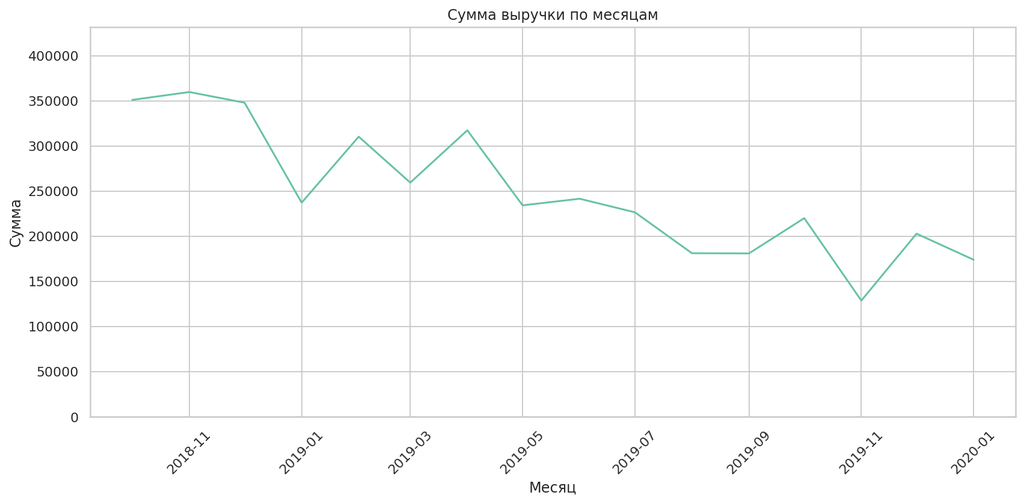

```python
# Извлекаем год и месяц для группировки
f_df['year_month'] = f_df['date'].dt.to_period('M')

# Группируем данные по 'year_month' и суммируем 'amount'
monthly_data = f_df.groupby('year_month')['amount'].sum().reset_index()

# Преобразуем 'year_month' обратно в datetime для построения графиков
monthly_data['year_month'] = monthly_data['year_month'].dt.to_timestamp()

# Строим график
sns.lineplot(data=monthly_data, x='year_month', y='amount')
plt.title('Сумма выручки по месяцам')
plt.xlabel('Месяц')
plt.ylabel('Сумма')
plt.ylim(0, monthly_data.amount.max() * 1.2)
plt.xticks(rotation=45)  # Поворачиваем метки по оси X, если необходимо
plt.tight_layout()  # Подгоняем график
plt.show()
```

Изучим динамику среднего чека.

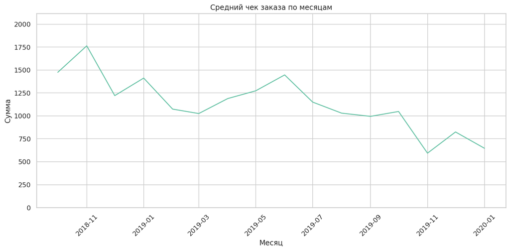

```python
# Группируем данные по 'year_month', 'order_id' и суммируем 'amount'
mean_receipt = f_df.groupby(['year_month', 'order_id'])['amount'].sum().reset_index()
mean_receipt = mean_receipt.groupby('year_month')['amount'].mean().reset_index()
mean_receipt['year_month'] = mean_receipt['year_month'].dt.to_timestamp()

# Строим график
sns.lineplot(data=mean_receipt, x='year_month', y='amount')
plt.title('Средний чек заказа по месяцам')
plt.xlabel('Месяц')
plt.ylabel('Сумма')
plt.ylim(0, mean_receipt.amount.max() * 1.2)
plt.xticks(rotation=45)  # Поворачиваем метки по оси X, если необходимо
plt.tight_layout()  # Подгоняем график
plt.show()
```

Динамика среднего чека имеет отрицательный тренд. При сравнении аналогичных периодов - ноябрь 2018 и ноябрь 2019 - снижение составило в 3 раза.

Дополнительно исследуем динамику количества заказов.

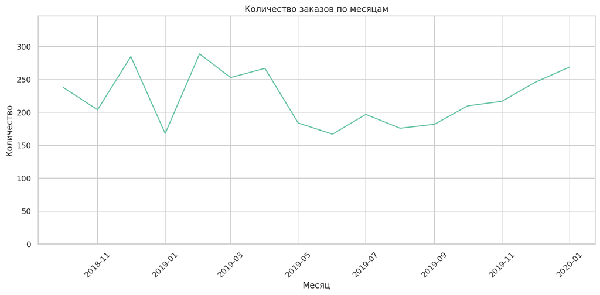

```python
# Группируем данные по 'year_month' и считаем 'order_id'
order_count = f_df.groupby('year_month')['order_id'].nunique().reset_index()
order_count['year_month'] = order_count['year_month'].dt.to_timestamp()

# Строим график
sns.lineplot(data=order_count, x='year_month', y='order_id')
plt.title('Количество заказов по месяцам')
plt.xlabel('Месяц')
plt.ylabel('Количество')
plt.ylim(0, order_count.order_id.max() * 1.2)
plt.xticks(rotation=45)  # Поворачиваем метки по оси X, если необходимо
plt.tight_layout()  # Подгоняем график
plt.show()
```

Следовательно, в интернет-магазине снизился средний чек при том же количестве заказов, что отразилось на выручке.

Исследуем помесячную динамику средней выручки с покупателя.

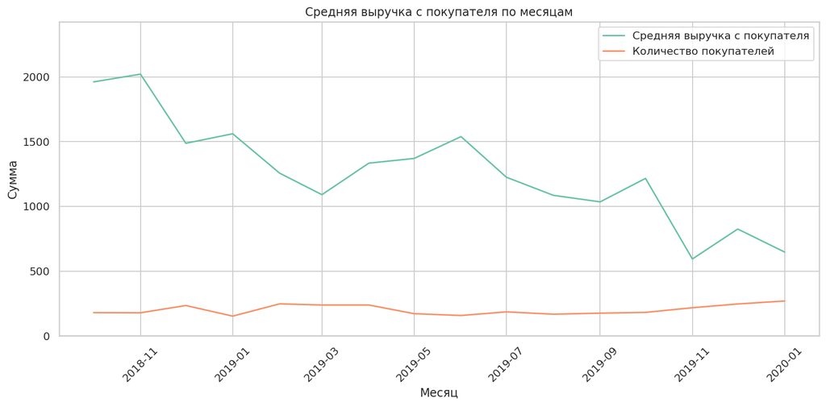

```python
# Группируем данные по 'year_month', 'order_id' и суммируем 'amount'
mean_revenue_by_customer = f_df.groupby(['year_month', 'customer_id'])['amount'].sum().reset_index()
mean_revenue_by_customer = mean_revenue_by_customer.groupby('year_month')['amount'].mean().reset_index()
mean_revenue_by_customer['year_month'] = mean_revenue_by_customer['year_month'].dt.to_timestamp()

customer_count = f_df.groupby('year_month')['customer_id'].nunique().reset_index()
customer_count['year_month'] = customer_count['year_month'].dt.to_timestamp()

# Строим график
sns.lineplot(data=mean_revenue_by_customer, x='year_month', y='amount', label='Средняя выручка с покупателя')
sns.lineplot(data=customer_count, x='year_month', y='customer_id', label='Количество покупателей')
plt.title('Средняя выручка с покупателя по месяцам')
plt.xlabel('Месяц')
plt.ylabel('Сумма')
plt.ylim(0, mean_revenue_by_customer.amount.max() * 1.2)
plt.xticks(rotation=45)  # Поворачиваем метки по оси X, если необходимо
plt.tight_layout()  # Подгоняем график
plt.show()
```

Динамика средний выручки с покупателя аналогична ситации со средним чеком: имеет пик в июне, но в целом отрицальтелный тренд с ноября 2018. При этом количество покупателей остается стабильным в течение всего времени. Для понимания сути отрицательного тренда исследуем в разрезе сегментации пользователей, категорий товаров и сезонности.

**Выводы:**

### Сегментация покупателей на основе истории их покупок

Cегментируем покупателей на основе [RFM подхода](https://timeweb.com/ru/community/articles/chto-takoe-rfm-analiz).

- R (от англ. recency – давность) – определяет, как давно была совершена сделка. Показывает, сколько прошло времени с последней покупки. Выделим 3 группы:
  - 1 – клиенты, которые совершали покупки более 6 месяцев назад - до августа 2019;
  - 2 – клиенты, которые сделали заказ от одного до 6 месяцев назад;
  - 3 – клиенты, которые совершили покупку до месяца назад.
- F (от англ. frequency – частота) – показывает, насколько часто клиент покупает товар или пользуется определенной услугой. Выделим 3 группы:
  - 1 – клиенты, которые совершили до 1 покупку;
  - 2 – клиенты, которые совершили от 2 до 5 покупок;
  - 3 – клиенты, которые совершили от 6 покупок.
- M (от англ. monetary – деньги) – общая вложенность средств в продукт или услугу. Выделим 3 группы:
  - 1 – клиенты, у которых сумма всех заказов до 25 процентиля;
  - 2 – клиенты, у которых сумма всех заказов от 25 до 75 процентиля;
  - 3 – клиенты, у которых сумма всех заказов от 75 процентиля.

Определим давность покупки.

```python
# Создадим список с последней датой покупки
customer_recency = f_df.groupby(['customer_id'])['year_month'].max().reset_index()

# Преобразуем столбец в тип данных datetime
customer_recency['year_month'] = customer_recency['year_month'].dt.to_timestamp()

# Создадим функцию для определения группы покупателя на основе признака давности
def classify_recency(year_month):
    if year_month == pd.to_datetime('2020-01-01'):
        return 3
    elif pd.to_datetime('2019-08-01') <= year_month < pd.to_datetime('2020-01-01'):
        return 2
    elif year_month < pd.to_datetime('2019-08-01'):
        return 1
    else:
        return 'unknown'

customer_recency['recency'] = customer_recency['year_month'].apply(classify_recency)
# Выводим случайные 5 строк
customer_recency.sample(5)
```

|  | customer_id | year_month | recency |
| --- | --- | --- | --- |
| 1742 | b75deecd-061f-434e-9686-a7f3a0b505ac | 2019-02-01 | 1 |
| 1246 | 843a7a49-5965-4336-b73e-46cbf92c2b41 | 2019-08-01 | 2 |
| 1100 | 73d1cd35-5e5f-4629-8cf2-3fda829d4e58 | 2019-10-01 | 2 |
| 2414 | fc333417-1d11-4a2a-b946-0957ae0603e9 | 2018-11-01 | 1 |
| 937 | 6362dd50-4d12-41a4-8534-44cb67c92ee3 | 2019-11-01 | 2 |

```python
# Оценим распределние по группам
customer_recency.groupby('recency')['customer_id'].nunique()
```

```
recency
1    1319
2     862
3     269
Name: customer_id, dtype: int64
```

Разница между группами не превышает 5 кратной велечины, что приемлемо. Следовательно по данному признаку можно проводить сегментацию.

Исследуем чатоту покупок и возможности сегментировать клиентов по данному признаку.

```python
(
    f_df
    .groupby('customer_id')['order_id'].nunique()
    .reset_index()
    .describe(percentiles=[.25, .5, .75, .9, .95, .99])
    .T
)
```

|  | count | mean | std | min | 25% | 50% | 75% | 90% | 95% | 99% | max |
| --- | --- | --- | --- | --- | --- | --- | --- | --- | --- | --- | --- |
| order_id | 2450.0 | 1.450204 | 2.678379 | 1.0 | 1.0 | 1.0 | 2.0 | 2.0 | 2.0 | 3.0 | 126.0 |

Исследуем признак общая вложенность средств клиентом.

```python
customer_monetary = f_df.groupby('customer_id')['amount'].sum().reset_index()
customer_monetary.describe(percentiles=[.25, .5, .75, .9, .95, .99]).T
```

|  | count | mean | std | min | 25% | 50% | 75% | 90% | 95% | 99% | max |
| --- | --- | --- | --- | --- | --- | --- | --- | --- | --- | --- | --- |
| amount | 2450.0 | 1621.966701 | 4310.652549 | 15.0 | 396.25 | 839.5 | 1798.0 | 3388.3 | 4870.85 | 9702.83 | 159508.0 |

Медианная общая выручка с клиента равна 839. 75% покупателей принесли магазину до 1798, 95% - до 4870. По данному признаку можно сделать сегментацию клиентов. Выделим клиентов в группы по сумме всех заказов: 1 - до 25 процентиля, 2 - от 25 до 75 процентиля, 3 - более 75 процентиля.

```python
# Создадим функцию для определения группы покупателя на основе признака общая вложенность средств
def classify_monetary(amount):
    if amount <= np.percentile(customer_monetary.amount, 25):
        return 1
    elif np.percentile(customer_monetary.amount, 25) < amount <= np.percentile(customer_monetary.amount, 75):
        return 2
    elif amount > np.percentile(customer_monetary.amount, 75):
        return 3
    else:
        return 'unknown'

customer_monetary['monetary'] = customer_monetary['amount'].apply(classify_monetary)
# Выводим случайные 5 строк
customer_monetary.sample(5)
```

|  | customer_id | amount | monetary |
| --- | --- | --- | --- |
| 1350 | 8eabcaca-e8c8-4eee-9079-4ff5f612273a | 3400.0 | 3 |
| 2439 | fe99fee2-d40c-4ef9-a589-8679f42076fa | 292.0 | 1 |
| 645 | 434e594a-91b7-4c0a-b7b8-c23e968030a9 | 307.0 | 1 |
| 1831 | bfacecbe-1f6c-435b-996c-a812f988cf65 | 1162.0 | 2 |
| 442 | 2e7b6794-3bb6-49c5-a3f5-897f7e4f581a | 142.0 | 1 |

Добавим классификации по группам в основной датафрейм.

```python
f_df = f_df.merge(customer_recency[['customer_id','recency']], how='left', on='customer_id')
f_df = f_df.merge(customer_monetary[['customer_id','monetary']], how='left', on='customer_id')
```

```python
# создаем стоблец с кодом группы
f_df['rm_group'] = f_df.apply(lambda x: str(x['recency']) + str(x['monetary']), axis=1)
f_df.head()
```

|  | date | customer_id | order_id | product | quantity | price | amount | category | season | year_month | recency | monetary | rm_group |
| --- | --- | --- | --- | --- | --- | --- | --- | --- | --- | --- | --- | --- | --- |
| 0 | 2018-10-01 | ee47d746-6d2f-4d3c-9622-c31412542920 | 68477 | Комнатное растение в горшке Алое Вера, d12, h30 | 1 | 142.0 | 142.0 | Садоводство и растения | Осень | 2018-10 | 1 | 2 | 12 |
| 1 | 2018-10-01 | ee47d746-6d2f-4d3c-9622-c31412542920 | 68477 | Комнатное растение в горшке Кофе Арабика, d12,... | 1 | 194.0 | 194.0 | Садоводство и растения | Осень | 2018-10 | 1 | 2 | 12 |
| 2 | 2018-10-01 | ee47d746-6d2f-4d3c-9622-c31412542920 | 68477 | Радермахера d-12 см h-20 см | 1 | 112.0 | 112.0 | Садоводство и растения | Осень | 2018-10 | 1 | 2 | 12 |
| 3 | 2018-10-01 | ee47d746-6d2f-4d3c-9622-c31412542920 | 68477 | Хризолидокарпус Лутесценс d-9 см | 1 | 179.0 | 179.0 | Садоводство и растения | Осень | 2018-10 | 1 | 2 | 12 |
| 4 | 2018-10-01 | ee47d746-6d2f-4d3c-9622-c31412542920 | 68477 | Циперус Зумула d-12 см h-25 см | 1 | 112.0 | 112.0 | Садоводство и растения | Осень | 2018-10 | 1 | 2 | 12 |

```python
# проверка результата по крайней даты по сегментам
f_df.groupby('rm_group')['date'].max().to_frame()
```

| rm_group | date |
| --- | --- |
| 11 | 2019-07-30 19:00:00 |
| 12 | 2019-07-31 13:00:00 |
| 13 | 2019-07-31 09:00:00 |
| 21 | 2019-12-31 11:00:00 |
| 22 | 2019-12-31 15:00:00 |
| 23 | 2019-12-31 20:00:00 |
| 31 | 2020-01-31 15:00:00 |
| 32 | 2020-01-31 12:00:00 |
| 33 | 2020-01-30 22:00:00 |

Проанализируем сегменты клиентов: количество покупателей, средний чек, основные продукты и категории.

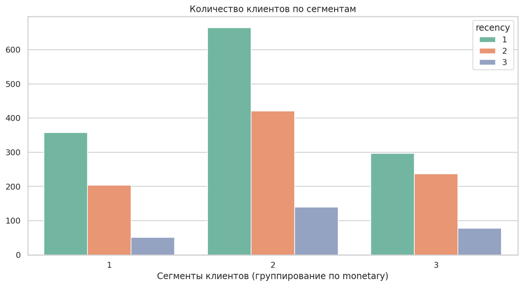

```python
# количество покупателей по сегментам клиентов
ax = sns.barplot(data=(
            f_df
            .groupby(['monetary', 'recency'])
            .agg(customer_cnt=('customer_id', 'nunique'))
            .reset_index()
            ),
 x='monetary', y='customer_cnt', hue='recency', palette='Set2');
ax.set_title('Количество клиентов по сегментам')  # Установка заголовка
ax.set_xlabel('Сегменты клиентов (группирование по monetary)')  # Установка подписи для оси X
ax.set_ylabel(None)
plt.show()
```

```python
(
    f_df
    .groupby('rm_group')
    .agg(customer_cnt=('customer_id', 'nunique'))
    .T
)
```

| rm_group | 11 | 12 | 13 | 21 | 22 | 23 | 31 | 32 | 33 |
| --- | --- | --- | --- | --- | --- | --- | --- | --- | --- |
| customer_cnt | 358 | 664 | 297 | 204 | 421 | 237 | 51 | 140 | 78 |

Клиенты, которые соверашли покупку очень давно (более 6 месяцев назад), образуют наиболее многочисленные сигменты: численность сегмента с низким чеком - 358, со средним чеком - 664, с высоким чеком - 297.

Клиенты, которые соверашли покупку давно (от месяца до полугода назад), сопоставима с первой группой: численность сегмента с низким чеком - 204, со средним чеком - 421, с высоким чеком - 237.

Клиенты, которые соверашли покупку недавно (месяц назад), образуют малочисленные группы: сегмент с низким чеком - 51, со средним чеком - 140, с высоким чеком - 78.

Количество покупателей по сегментам из последнего класса напорядок отличается от остальных, что сильно ограничивает достоверность результатов при проверке гипотез, в связи с чем они будут исключены из нее.

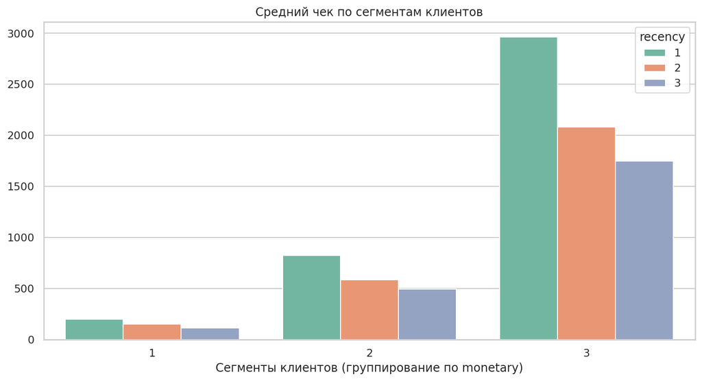

```python
# средний чек по сегментам клиентов
ax = sns.barplot(data=(
            f_df
            .groupby(['monetary', 'recency', 'order_id'])['amount'].sum()
            .groupby(level=[0, 1]).mean()
            .reset_index()
            ),
 x='monetary', y='amount', hue='recency', palette='Set2');
ax.set_title('Cредний чек по сегментам клиентов')  # Установка заголовка
ax.set_xlabel('Сегменты клиентов (группирование по monetary)')  # Установка подписи для оси X
ax.set_ylabel(None)
plt.show()
```

```python
(
    f_df
    .groupby(['rm_group', 'order_id'])['amount'].sum()
    .groupby(level=0).mean()
    .to_frame()
    .T
    .round(2)
)
```

| rm_group | 11 | 12 | 13 | 21 | 22 | 23 | 31 | 32 | 33 |
| --- | --- | --- | --- | --- | --- | --- | --- | --- | --- |
| amount | 199.07 | 825.31 | 2962.32 | 148.95 | 584.78 | 2079.9 | 112.67 | 494.64 | 1746.47 |

Средний чек клиентов, которые соверашли покупку очень давно (более 6 месяцев назад), составляет соответственно сегментам 11 - 199, 12 - 825, 13 - 2962.

Средний чек клиентов, которые соверашли покупку давно (до полугода назад), составляет соответственно сегменту 21 - 149, 22 - 585, 23 - 2080.

Средний чек клиентов, которые соверашли покупку недавно (месяц назад), составляет соответственно сигменту 31 - 113, 32 - 495, 33 - 1747. Траты клиентов заметно снизились. Проверим достоверность тренда с помощью статистического метода.

Дополнительно проведем исследование, как распределяется среднее количество заказов на покупателя по сегментам.

```python
(
    f_df
    .groupby(['rm_group', 'customer_id'])
    .agg(order_cnt=('order_id', 'nunique'))
    .groupby(level=0)[['order_cnt']]
    .mean()
    .T
    .round(1)
)
```

| rm_group | 11 | 12 | 13 | 21 | 22 | 23 | 31 | 32 | 33 |
| --- | --- | --- | --- | --- | --- | --- | --- | --- | --- |
| order_cnt | 1.1 | 1.1 | 1.8 | 1.4 | 1.6 | 1.8 | 2.0 | 2.0 | 2.0 |

Интересно, что независимо от бюджета, очень активные клиенты совершали в среднем по 2 заказа.

Давние клиенты с малым и средним бюджетом сделали в среднем 1,4 и 1,6 заказов соответственно, тогда как из того же класса клиенты с высоким бюджетом - 1,8.

Сегмент покупателей, которые совершали покупку очень давно с низким и средним чеком, в среднем совершили 1,1 заказа, тогда как клиенты с высоким чеком - 1,8.

Теперь проанализируем на основе количества топ 3 покупаемых товаров по сегментам клиентов.

```python
(
    f_df
    .groupby(['rm_group', 'product'])['quantity'].sum()
    .groupby(level=0).nlargest(3)
    .reset_index(level=0, drop=True)
    .to_frame()
)
```

| rm_group | product | quantity |
| --- | --- | --- |
| 11 | Цветок искусственный Гвоздика пластиковая одиночная в ассортименте 50 см | 30 |
|  | Муляж Персики мини полиуретан d-6 см | 21 |
|  | Цветок искусственный Крокус 20 см | 17 |
| 12 | Ёрш унитазный с деревянной ручкой , Ваир 1712012 | 83 |
|  | Насадка на валик ВММ-200/60 белый искусственный мех, 0703011 | 70 |
|  | Вешалка-плечики без эссенции цвет тёмно-розовый FWM-002/Quartz pink | 60 |
| 13 | Муляж ЯБЛОКО 9 см красное | 610 |
|  | Вешалки мягкие для деликатных вещей 3 шт шоколад | 334 |
|  | Ручка-скоба РС-100 белая *Трибатрон*, 1108035 | 200 |
| 21 | Цветок искусственный Гвоздика пластиковая одиночная в ассортименте 50 см | 16 |
|  | Искусственный цветок Роза закрытая малая пластиковая белая | 15 |
|  | Пеларгония розебудная Red Pandora укорененный черенок | 13 |
| 22 | Искусственный цветок Роза закрытая малая пластиковая белая | 30 |
|  | Цветок искусственный Нарцисс одиночный в ассортименте 35 см | 25 |
|  | Уголок оконный 100х100 мм медь антик с полимерным покрытием *Тонар*, 1109038 | 24 |
| 23 | Муляж Яблоко зеленый 9 см полиуретан | 210 |
|  | Крепеж для пружины дверной оцинкованный, 1107054 | 100 |
|  | Шпингалет 80 мм белый с пружиной, 1102188 | 100 |
| 31 | Пеларгония зональная Ринго Вайт d-7 см h-10 см укорененный черенок | 7 |
|  | Пеларгония розебудная Red Pandora укорененный черенок | 7 |
|  | Пеларгония розебудная Prins Nikolai укорененный черенок | 4 |
| 32 | Тележка багажная DELTA DT-22 синий грузоподъемность 20 кг сумка и 50 кг каркас РОССИЯ | 6 |
|  | Роза садовая чайногибридная в горшке Керио | 4 |
|  | Сушилка для белья потолочная Лиана 2,0 м 1703009 | 4 |
| 33 | Гладильная доска НИКА BLUES 124х46 см 5757 | 3 |
|  | Корзина для белья ВИОЛЕТ угловая с крышкой Ротанг 60 л белая 2350/6 | 3 |
|  | Полки QWERTY Рио белый/чёрный 42,5х21х10 см 17х17х10 см 17х17х10 см 72005 | 3 |

Клиенты, которые соверашли покупку очень давно (более 6 месяцев назад):

- и низким средним чеком, покупали чаще всего цветки искусственные и муляж Персика;
- клиенты со средним чеком заказывывали обычно ерш, насадку на валик и вешалки;
- клиенты с высоким средним чеком приобретали муляж Яблока, вешалки и Ручку-скобу.

Клиенты, которые соверашли покупку давно (до полугода назад):

- и низким средним чеком, покупали чаще всего цветки искусственные и Пеларгонию;
- клиенты со средним чеком заказывывали обычно уголок оконный, и цветки искусственные;
- клиенты с высоким средним чеком приобретали муляж Яблока, крепеж и шпингалет.

Клиенты, которые соверашли покупку недавно (месяц назад):

- и низким средним чеком, покупали чаще всего растение Пеларгония;
- клиенты со средним чеком заказывывали обычно тележки, розы садовые и сушилки;
- клиенты с высоким средним чеком приобретали гладильные доски, корзины для белья и полки.

Проанализируем на основе количества популярные категории товаров среди сегментов клиентов.

```python
(
    f_df
    .groupby(['rm_group', 'category'])['quantity'].sum()
    .groupby(level=0).nlargest(1)
    .reset_index(level=0, drop=True)
    .to_frame()
)
```

| rm_group | category | quantity |
| --- | --- | --- |
| 11 | Садоводство и растения | 319 |
| 12 | Садоводство и растения | 1716 |
| 13 | Садоводство и растения | 1559 |
| 21 | Садоводство и растения | 191 |
| 22 | Садоводство и растения | 371 |
| 23 | Декор и интерьер | 322 |
| 31 | Садоводство и растения | 72 |
| 32 | Садоводство и растения | 91 |
| 33 | Бытовая техника и электроника | 48 |

Клиенты, которые соверашли покупку очень давно (более 6 месяцев назад), независимо от бюждета чащего всего покупали товары из категории "Садоводство и растения".

Клиенты, которые соверашли покупку давно (до полугода назад):

- и низким и средним чеком покупали чаще всего товары из категории "Садоводство и растения";
- клиенты с высоким средним чеком приобретали товары из категории "Декор и интерьер".

Клиенты, которые соверашли покупку недавно (месяц назад):

- и низким и средним чеком покупали чаще всего товары из категории "Садоводство и растения";
- клиенты с высоким средним чеком приобретали товары из категории "Бытовая техника и электроника".

Проанализируем на основе количества популярные категории товаров в течение сезонов по выделенным сегментам покупателей.

```python
category_by_season.season.unique()
```

```
array(['Весна', 'Зима', 'Лето', 'Осень'], dtype=object)
```

```python
category_by_season = (
    f_df
    .groupby(['rm_group', 'season', 'category'])['quantity'].sum()
    .groupby(['rm_group', 'season']).nlargest(1)
    .reset_index(level=[2,3], drop=True)
    .to_frame()
    .rename(columns={'category':'count'})
    .reset_index()
)

pd.crosstab(category_by_season.season,
            category_by_season.rm_group,
            category_by_season.category,
            aggfunc='first').reindex(['Весна', 'Лето', 'Осень', 'Зима'])
```

| rm_group season | 11 | 12 | 13 | 21 | 22 | 23 | 31 | 32 | 33 |
| --- | --- | --- | --- | --- | --- | --- | --- | --- | --- |
| Весна | Декор и интерьер | Садоводство и растения | Садоводство и растения | Садоводство и растения | Бытовая техника и электроника | Садоводство и растения | Садоводство и растения | Домашний текстиль | Организация и хранение |
| Лето | Садоводство и растения | Садоводство и растения | Организация и хранение | Садоводство и растения | Садоводство и растения | Организация и хранение | Садоводство и растения | Бытовая техника и электроника | Бытовая техника и электроника |
| Осень | Садоводство и растения | Садоводство и растения | Декор и интерьер | Садоводство и растения | Садоводство и растения | Декор и интерьер | Садоводство и растения | Бытовая техника и электроника | Организация и хранение |
| Зима | Садоводство и растения | Садоводство и растения | Уборка и клининг | Садоводство и растения | Садоводство и растения | Организация и хранение | Садоводство и растения | Садоводство и растения | Бытовая техника и электроника |

- **Весной** категория "Садоводство и растения" популярна у сегментов клиентов 31, 21, 23, 12, 13, "Домашний текстиль" - у 32, "Организация и хранение" - 33, "Бытовая техника и электроника" - 22, "Декор и интерьер" - 11.
- **Летом** категория "Садоводство и растения" популярна у сегментов 31, 21, 22, 11, 12, "Бытовая техника и электроника" - 32 и 33, "Организация и хранение" - 23, 13.
- **Осенью** категория "Садоводство и растения" популярна у сегментов 31, 21, 22, 11, 12, "Бытовая техника и электроника" - 32, "Организация и хранение" - 33, "Декор и интерьер" - 23, 13.
- **Зимой** категория "Садоводство и растения" популярна у сегментов 31,32,21,22,11,12, "Бытовая техника и электроника" - 33, "Организация и хранение" - 23, "Уборка и клининг" - 13.

Построим график динамики по месяцам популярности категорий продукции по сегментам клиентов.

```python
# создадим палитру для цветового единообразия категорий товаров
colors = {}
for i in range(len(f_df.category.unique())):
    colors[f_df.category.unique()[i]] = sns.color_palette('tab20')[i]
```

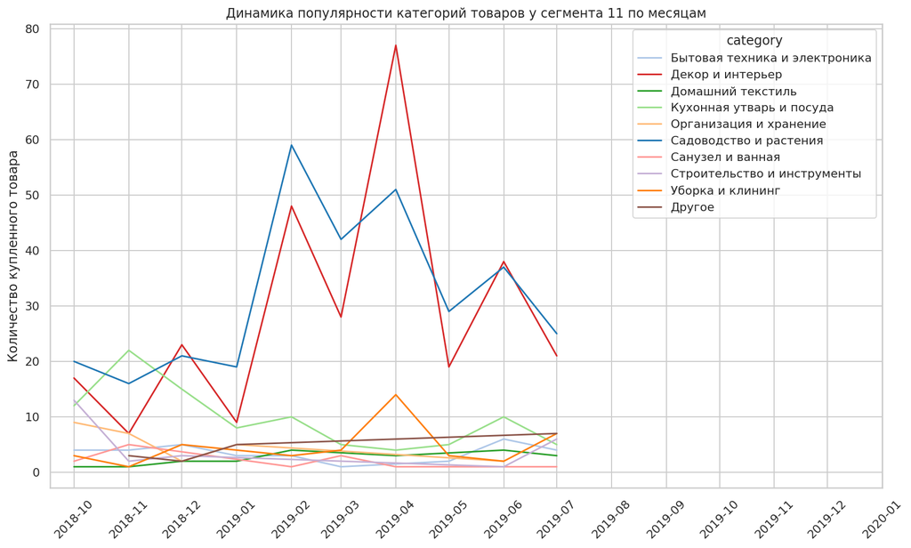

| year_month | category |
| --- | --- |
| 2018-10-01 | Садоводство и растения |
| 2018-11-01 | Кухонная утварь и посуда |
| 2018-12-01 | Декор и интерьер |
| 2019-01-01 | Садоводство и растения |
| 2019-02-01 | Садоводство и растения |
| 2019-03-01 | Садоводство и растения |
| 2019-04-01 | Декор и интерьер |
| 2019-05-01 | Садоводство и растения |
| 2019-06-01 | Декор и интерьер |
| 2019-07-01 | Садоводство и растения |

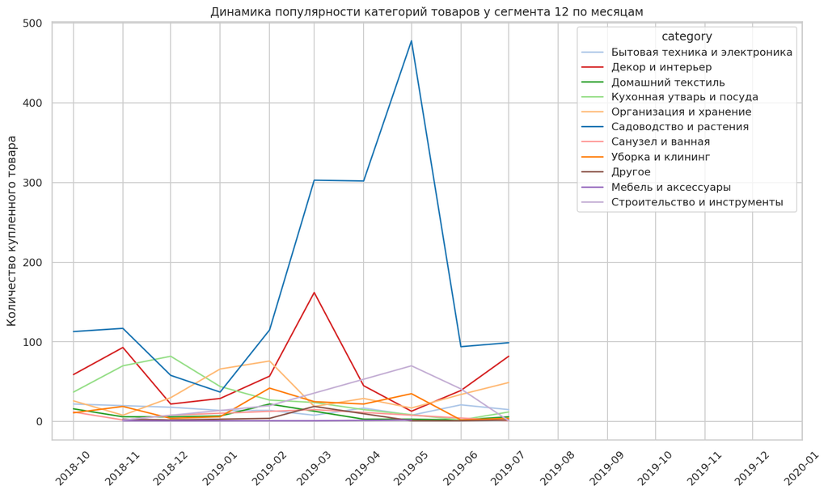

| year_month | category |
| --- | --- |
| 2018-10-01 | Садоводство и растения |
| 2018-11-01 | Садоводство и растения |
| 2018-12-01 | Кухонная утварь и посуда |
| 2019-01-01 | Организация и хранение |
| 2019-02-01 | Садоводство и растения |
| 2019-03-01 | Садоводство и растения |
| 2019-04-01 | Садоводство и растения |
| 2019-05-01 | Садоводство и растения |
| 2019-06-01 | Садоводство и растения |
| 2019-07-01 | Садоводство и растения |

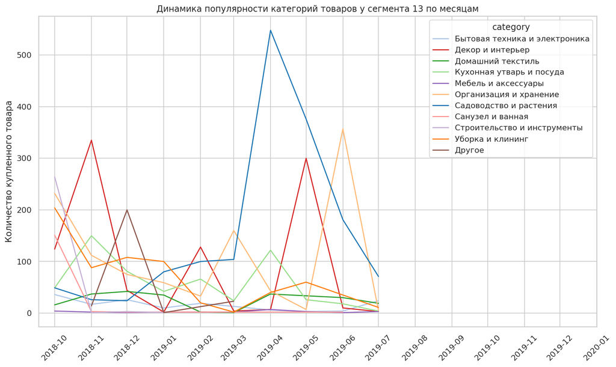

| year_month | category |
| --- | --- |
| 2018-10-01 | Строительство и инструменты |
| 2018-11-01 | Декор и интерьер |
| 2018-12-01 | Другое |
| 2019-01-01 | Уборка и клининг |
| 2019-02-01 | Декор и интерьер |
| 2019-03-01 | Организация и хранение |
| 2019-04-01 | Садоводство и растения |
| 2019-05-01 | Садоводство и растения |
| 2019-06-01 | Организация и хранение |
| 2019-07-01 | Садоводство и растения |

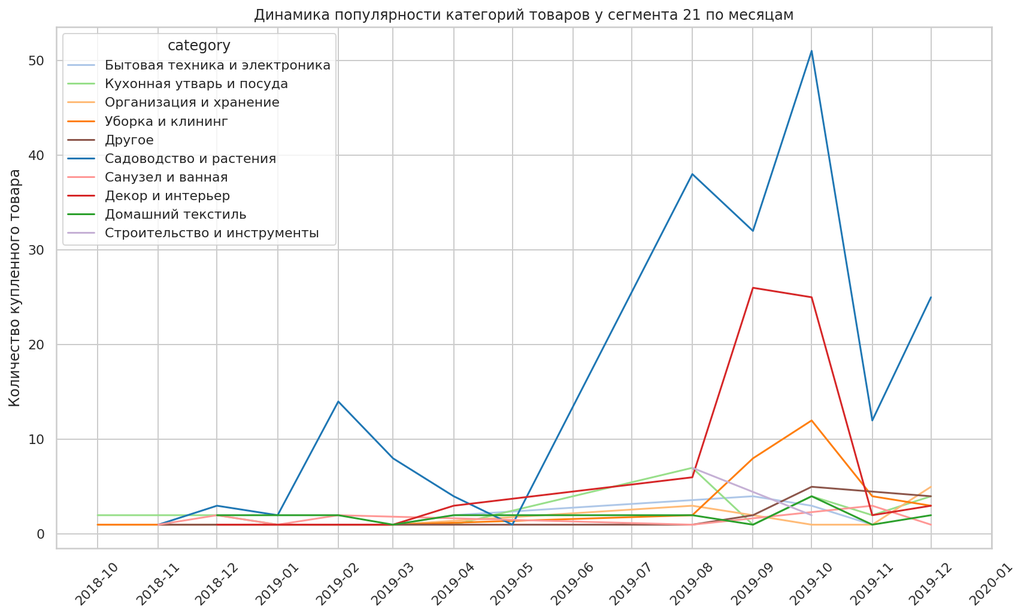

| year_month | category |
| --- | --- |
| 2018-10-01 | Кухонная утварь и посуда |
| 2018-11-01 | Бытовая техника и электроника |
| 2018-12-01 | Садоводство и растения |
| 2019-01-01 | Садоводство и растения |
| 2019-02-01 | Садоводство и растения |
| 2019-03-01 | Садоводство и растения |
| 2019-04-01 | Садоводство и растения |
| 2019-05-01 | Садоводство и растения |
| 2019-08-01 | Садоводство и растения |
| 2019-09-01 | Садоводство и растения |
| 2019-10-01 | Садоводство и растения |
| 2019-11-01 | Садоводство и растения |
| 2019-12-01 | Садоводство и растения |

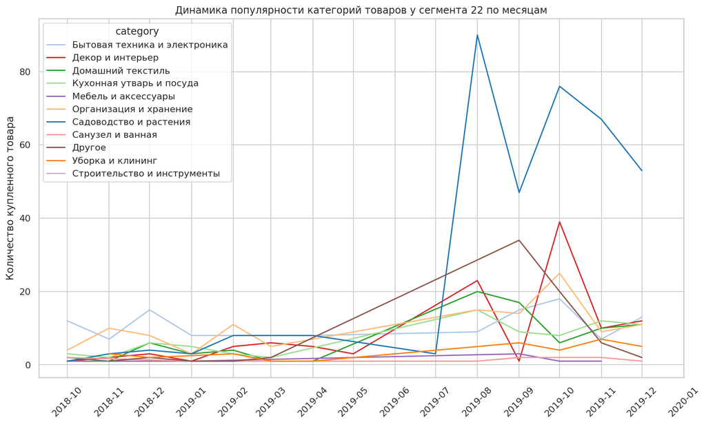

| year_month | category |
| --- | --- |
| 2018-10-01 | Бытовая техника и электроника |
| 2018-11-01 | Организация и хранение |
| 2018-12-01 | Бытовая техника и электроника |
| 2019-01-01 | Бытовая техника и электроника |
| 2019-02-01 | Организация и хранение |
| 2019-03-01 | Бытовая техника и электроника |
| 2019-04-01 | Бытовая техника и электроника |
| 2019-05-01 | Декор и интерьер |
| 2019-07-01 | Садоводство и растения |
| 2019-08-01 | Садоводство и растения |
| 2019-09-01 | Садоводство и растения |
| 2019-10-01 | Садоводство и растения |
| 2019-11-01 | Садоводство и растения |
| 2019-12-01 | Садоводство и растения |

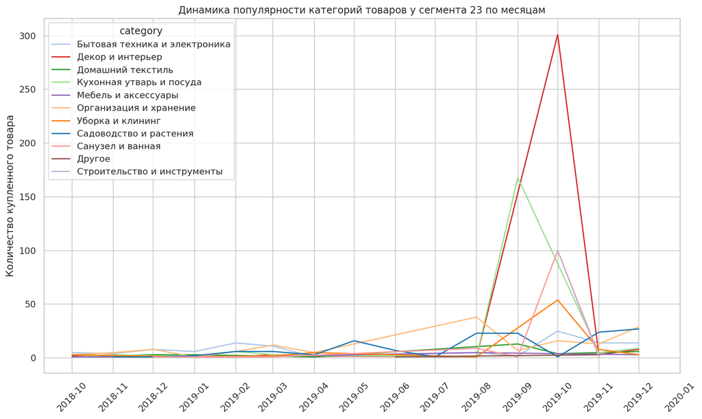

| year_month | category |
| --- | --- |
| 2018-10-01 | Бытовая техника и электроника |
| 2018-11-01 | Организация и хранение |
| 2018-12-01 | Бытовая техника и электроника |
| 2019-01-01 | Бытовая техника и электроника |
| 2019-02-01 | Бытовая техника и электроника |
| 2019-03-01 | Организация и хранение |
| 2019-04-01 | Организация и хранение |
| 2019-05-01 | Садоводство и растения |
| 2019-06-01 | Садоводство и растения |
| 2019-07-01 | Садоводство и растения |
| 2019-08-01 | Организация и хранение |
| 2019-09-01 | Кухонная утварь и посуда |
| 2019-10-01 | Декор и интерьер |
| 2019-11-01 | Садоводство и растения |
| 2019-12-01 | Организация и хранение |

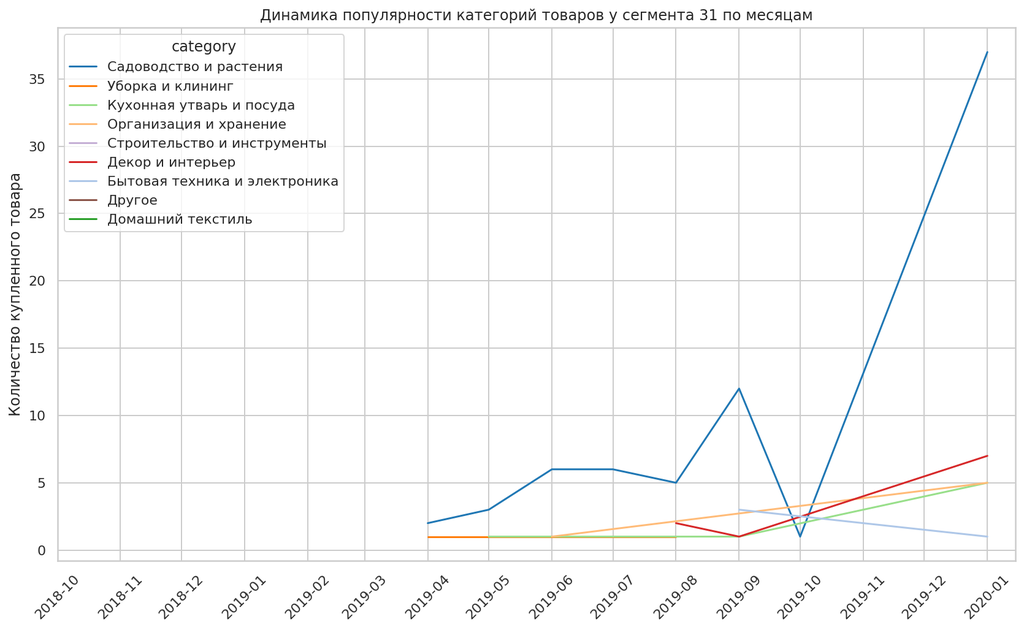

| year_month | category |
| --- | --- |
| 2019-04-01 | Садоводство и растения |
| 2019-05-01 | Садоводство и растения |
| 2019-06-01 | Садоводство и растения |
| 2019-07-01 | Садоводство и растения |
| 2019-08-01 | Садоводство и растения |
| 2019-09-01 | Садоводство и растения |
| 2019-10-01 | Садоводство и растения |
| 2020-01-01 | Садоводство и растения |

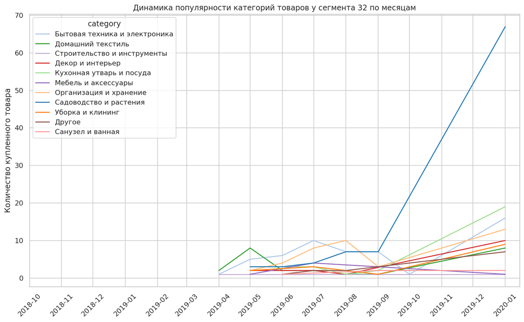

| year_month | category |
| --- | --- |
| 2019-04-01 | Домашний текстиль |
| 2019-05-01 | Домашний текстиль |
| 2019-06-01 | Бытовая техника и электроника |
| 2019-07-01 | Бытовая техника и электроника |
| 2019-08-01 | Организация и хранение |
| 2019-09-01 | Бытовая техника и электроника |
| 2019-10-01 | Бытовая техника и электроника |
| 2020-01-01 | Садоводство и растения |

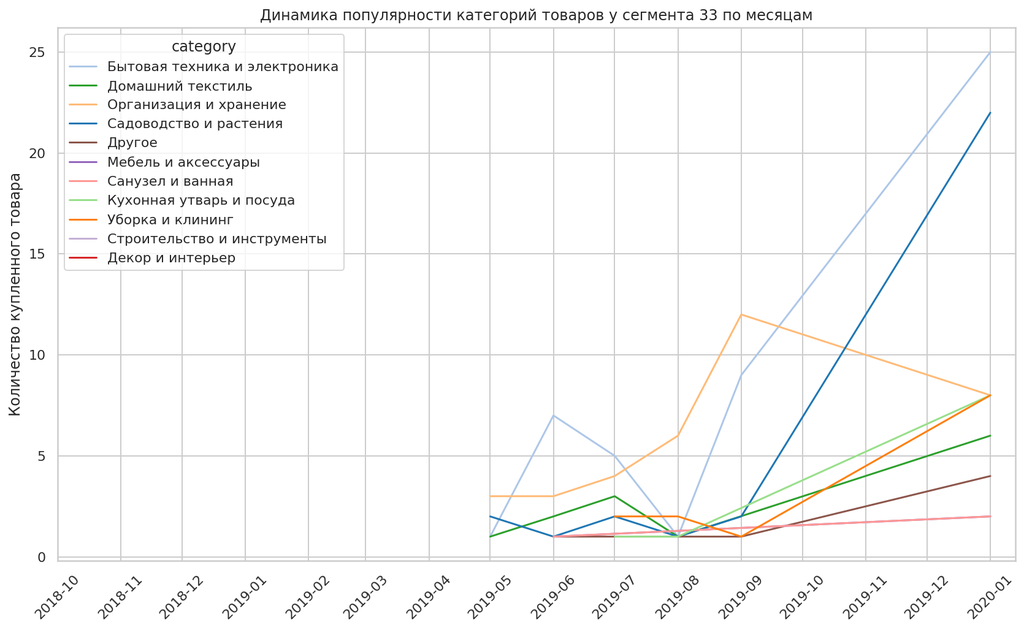

| year_month | category |
| --- | --- |
| 2019-05-01 | Организация и хранение |
| 2019-06-01 | Бытовая техника и электроника |
| 2019-07-01 | Бытовая техника и электроника |
| 2019-08-01 | Организация и хранение |
| 2019-09-01 | Организация и хранение |
| 2020-01-01 | Бытовая техника и электроника |

```python
popular_categories = (
    f_df
    .groupby(['rm_group', 'year_month', 'category'])['quantity'].sum()
    .reset_index()
)

popular_categories['year_month'] = popular_categories['year_month'].dt.to_timestamp()
# создадим список месяцов для стандартизации оси X
months = popular_categories['year_month'].unique()

for group in popular_categories.rm_group.unique():
    plt.figure(figsize=(14,8))
    sns.lineplot(data=popular_categories.query('rm_group == @group'),
     x='year_month', y='quantity', hue='category', palette=colors, markers='o');
    plt.title('Динамика популярности категорий товаров у сегмента {} по месяцам'.format(group))
    plt.xticks(months, rotation=45)
    # Форматирование оси x для отображения только года и месяца
    plt.gca().xaxis.set_major_formatter(mdates.DateFormatter('%Y-%m'))
    plt.xlabel(None)
    plt.ylabel('Количество купленного товара')
    plt.show()
    # выведим в виде таблицы популярные категории товаров по месяцам по сегментам клиентов
    display(
                popular_categories
                .query('rm_group == @group')
                .drop(columns='rm_group')
                .groupby(['year_month', 'category'])['quantity'].first()
                .groupby(level=0).nlargest(1)
                .reset_index(level=0, drop=True)
                .to_frame()
                .drop(columns='quantity')
            )
```

На основе данных популярности категорий товаров по месяцам можно сделать следующие выводы по сегментам клиентов:

**Сегмент 11:**

- С января по март - Садоводство и растения
- Апрель - Декор и интерьер
- Май - Садоводство и растения
- Июнь - Декор и интерьер
- С июля по октябрь - Садоводство и растения
- Ноябрь - Кухонная утварь и посуда
- Декабрь - Декор и интерьер

**Сегмент 12:**

- Январь - Организация и хранение
- С февраля по ноябрь - Садоводство и растения
- Декабрь - Кухонная утварь и посуда

**Сегмент 13:**

- Январь - Уборка и клининг
- Февраль - Декор и интерьер
- Март - Организация и хранение
- Апрель - Садоводство и растения
- Октябрь - Строительство и инструменты
- Ноябрь - Декор и интерьер
- Декабрь - Разное

**Сегмент 21:**

- Январь - Садоводство и растения
- Октябрь - Кухонная утварь и посуда
- Ноябрь - Бытовая техника и электроника
- Декабрь - Садоводство и растения

**Сегмент 22:**

- Январь - Бытовая техника и электроника
- Февраль - Организация и хранение
- Март-апрель - Бытовая техника и электроника
- Май - Декор и интерьер
- С июня по сентябрь - Садоводство и растения
- Октябрь - Бытовая техника и электроника
- Ноябрь - Организация и хранение
- Декабрь - Бытовая техника и электроника

**Сегмент 23:**

- Январь-февраль - Бытовая техника и электроника
- Март-апрель - Организация и хранение
- С мая по июль - Садоводство и растения
- Август - Организация и хранение
- Сентябрь - Кухонная утварь и посуда
- Октябрь - Декор и интерьер, Бытовая техника и электроника
- Ноябрь - Садоводство и растения, Организация и хранение
- Декабрь - Организация и хранение, Бытовая техника и электроника

**Сегмент 31:**

- в течение всего года актуальным является категория товаров Садоводство и растения.

**Сегмент 32:**

- Январь - Садоводство и растения
- Апрель и май - Домашний текстиль
- Июнь-июль - Бытовая техника и электроника
- Август - Организация и хранение
- Сентябрь-октябрь Бытовая техника и электроника

**Сегмент 33:**

- Январь - Бытовая техника и электроника
- Май - Организация и хранение
- Июнь-июль - Бытовая техника и электроника
- Август-сентябрь - Организация и хранение

**Выводы:**

## Проверка гипотез

Сформулируем гипотезы для эксперимента и проверим:

- H<sub>0</sub>: Сегменты клиентов не различаются по категориям товаров
- H<sub>1</sub>: Сегменты клиентов различаются по категориям товаров
- H<sub>0</sub>: Сегменты клиентов не различаются по среднему чеку
- H<sub>1</sub>: Сегменты клиентов различаются по среднему чеку

С учетом количества клиентов и сегментов установим целевую статисчискую значимость на уровне 0,1 и рассчитаем с учетом поправки метода Бонферрони (поправка Бонферрони) для 6 групп: 11, 12, 13, 21, 22, 23. Группы 31, 32, 33 были исключены из проверки связи с недостаточной численностью.

```python
target_alpha = 0.1
test_group = 6
pair_combinations = math.comb(test_group, 2)
alpha = round(target_alpha / pair_combinations, 3)
print(f'Целевой уровень значимости {target_alpha} с учетом поправки метода Бонферрони при количестве попарных сравнений {pair_combinations} равен {alpha}.')
```

```
Целевой уровень значимости 0.1 с учетом поправки метода Бонферрони при количестве попарных сравнений 15 равен 0.007.
```

```python
# Создадим функцию для расчета статистической значимости между группами

def z_test(sample_size_1, group_size_1, sample_size_2, group_size_2, alpha=alpha):
    """
    функция производит рассчет z теста.
    Принимает размерность признака групп и численность групп.
    Уровень значимости задан по умолчанию с учетом поправки Бонферрони.
    """

    p_1 = sample_size_1 / group_size_1
    p_2 = sample_size_2 / group_size_2

    difference = p_1 - p_2
    p_comb = (sample_size_1 + sample_size_2) / (group_size_1 + group_size_2)
    z_value = difference / math.sqrt(p_comb * (1 - p_comb) * (1 / group_size_1 + 1 / group_size_2))
    distr = st.norm(0, 1)
    p_value = (1 - distr.cdf(abs(z_value))) * 2

    print(f"Гипотеза 1: z-статистика = {z_value:.2f}, p-значение = {p_value:.3f}.")

    if p_value < alpha:
        print(f'Отклоняем нулевую гипотезу, сегменты клиентов различаются по признаку.')
    else:
        print(f'Не отклоняем нулевую гипотезу, сегменты клиентов не различаются по признаку.')
```

Проверим первую гипотезу:

- H<sub>0</sub>: Сегменты клиентов не различаются по категориям товаров
- H<sub>1</sub>: Сегменты клиентов различаются по категориям товаров

Используем z тест, так как сравниваем доли сегментов.

```python
# создаем датафрейм с размерами сегментов клиентов
customer_group_cnt = (
    f_df[~f_df['rm_group'].isin(['31','32','33'])]
    .groupby('rm_group').agg(customer_cnt=('customer_id', 'nunique'))
)
customer_group_cnt
```

| rm_group | customer_cnt |
| --- | --- |
| 11 | 358 |
| 12 | 664 |
| 13 | 297 |
| 21 | 204 |
| 22 | 421 |
| 23 | 237 |

Создадим датафрейм с попуплярной категорией товаров по сегментам клиентов. Для этого просуммируем по количеству позиции, сгруппировав по категории и покупателю. Выделим самый популярную категорию у каждого клиента. Подсчитаем количество клиентов по категориям товаров и выведем таким образом самую популярную категорию товаров для каждого сегментам клиентов.

```python
# создаем датафрейм с самой популярной категорией и ее частотностью по сегментов клиентов
top_category_by_group = (
    f_df[~f_df['rm_group'].isin(['31','32','33'])]
    .groupby(['rm_group', 'customer_id', 'category'])['quantity'].sum()
    .groupby(level=[0,1]).nlargest(1)
    .reset_index(level=[0,1], drop=True)
    .reset_index()
    .groupby('rm_group')['category'].value_counts()
    .groupby(level=0).nlargest(1)
    .reset_index(level=0, drop=True)
    .to_frame()
    .rename(columns={'category':'count'})
    .reset_index()
)
top_category_by_group
```

|  | rm_group | category | count |
| --- | --- | --- | --- |
| 0 | 11 | Садоводство и растения | 137 |
| 1 | 12 | Садоводство и растения | 238 |
| 2 | 13 | Организация и хранение | 76 |
| 3 | 21 | Садоводство и растения | 90 |
| 4 | 22 | Бытовая техника и электроника | 113 |
| 5 | 23 | Бытовая техника и электроника | 79 |

Создадим цикл для проверки гипотез о различии категорий между сегментами клиентов. При одинаковых категориях, такая проверка будет пропущена.

```python
for i in top_category_by_group.index:
    for group_2 in top_category_by_group.loc[top_category_by_group.index > i, 'rm_group']:
        group_1 = top_category_by_group.loc[i, 'rm_group']
        if top_category_by_group.query('rm_group == @group_1')['category'].values[0] == top_category_by_group.query('rm_group == @group_2')['category'].values[0]:
            continue
        print(f'Сравнение сегментов клиентов {group_1} и {group_2} по категориям товаров.',
              'У сегмента клиентов {} популярная категория "{}".'.format(group_1,
                                                                         top_category_by_group.query('rm_group == @group_1')['category'].values[0]),
              'У сегмента клиентов {} популярная категория "{}".'.format(group_2,
                                                                         top_category_by_group.query('rm_group == @group_2')['category'].values[0]),
              sep='\n')
        z_test(
            top_category_by_group.query('rm_group == @group_1')['count'].values[0],
            customer_group_cnt.loc[group_1, 'customer_cnt'],
            top_category_by_group.query('rm_group == @group_2')['count'].values[0],
            customer_group_cnt.loc[group_2, 'customer_cnt']
        )
        print('\n', '-'*100, '\n')
```

```
Сравнение сегментов клиентов 11 и 13 по категориям товаров.
У сегмента клиентов 11 популярная категория "Садоводство и растения".
У сегмента клиентов 13 популярная категория "Организация и хранение".
Гипотеза 1: z-статистика = 3.45, p-значение = 0.001.
Отклоняем нулевую гипотезу, сегменты клиентов различаются по признаку.

 ----------------------------------------------------------------------------------------------------

Сравнение сегментов клиентов 11 и 22 по категориям товаров.
У сегмента клиентов 11 популярная категория "Садоводство и растения".
У сегмента клиентов 22 популярная категория "Бытовая техника и электроника".
Гипотеза 1: z-статистика = 3.40, p-значение = 0.001.
Отклоняем нулевую гипотезу, сегменты клиентов различаются по признаку.

 ----------------------------------------------------------------------------------------------------

Сравнение сегментов клиентов 11 и 23 по категориям товаров.
У сегмента клиентов 11 популярная категория "Садоводство и растения".
У сегмента клиентов 23 популярная категория "Бытовая техника и электроника".
Гипотеза 1: z-статистика = 1.23, p-значение = 0.220.
Не отклоняем нулевую гипотезу, сегменты клиентов не различаются по признаку.

 ----------------------------------------------------------------------------------------------------

Сравнение сегментов клиентов 12 и 13 по категориям товаров.
У сегмента клиентов 12 популярная категория "Садоводство и растения".
У сегмента клиентов 13 популярная категория "Организация и хранение".
Гипотеза 1: z-статистика = 3.13, p-значение = 0.002.
Отклоняем нулевую гипотезу, сегменты клиентов различаются по признаку.

 ----------------------------------------------------------------------------------------------------

Сравнение сегментов клиентов 12 и 22 по категориям товаров.
У сегмента клиентов 12 популярная категория "Садоводство и растения".
У сегмента клиентов 22 популярная категория "Бытовая техника и электроника".
Гипотеза 1: z-статистика = 3.09, p-значение = 0.002.
Отклоняем нулевую гипотезу, сегменты клиентов различаются по признаку.

 ----------------------------------------------------------------------------------------------------

```

[output cut: 32 more lines]

```
Сравнение сегментов клиентов 21 и 22 по категориям товаров.
У сегмента клиентов 21 популярная категория "Садоводство и растения".
У сегмента клиентов 22 популярная категория "Бытовая техника и электроника".
Гипотеза 1: z-статистика = 4.32, p-значение = 0.000.
Отклоняем нулевую гипотезу, сегменты клиентов различаются по признаку.

 ----------------------------------------------------------------------------------------------------

Сравнение сегментов клиентов 21 и 23 по категориям товаров.
У сегмента клиентов 21 популярная категория "Садоводство и растения".
У сегмента клиентов 23 популярная категория "Бытовая техника и электроника".
Гипотеза 1: z-статистика = 2.32, p-значение = 0.020.
Не отклоняем нулевую гипотезу, сегменты клиентов не различаются по признаку.

 ----------------------------------------------------------------------------------------------------
```

Различия по категориям товаров при уровне значимости 0,1 были обнаружены между сегментами клиентов:

- 21 и 22: первая группа предпочитает товары из "Садоводство и растения", вторая - "Бытовая техника и электроника";
- 21 и 13: первая группа предпочитает товары из "Садоводство и растения", вторая - "Организация и хранение";
- 22 и 11: первая группа предпочитает товары из "Бытовая техника и электроника", вторая - "Садоводство и растения";
- 22 и 12: первая группа предпочитает товары из "Бытовая техника и электроника", вторая - "Садоводство и растения";
- 11 и 13: первая группа предпочитает товары из "Садоводство и растения", вторая - "Организация и хранение";
- 12 и 13: первая группа предпочитает товары из "Садоводство и растения", вторая - "Организация и хранение".